# Flanker MLMs

PD Inhibition Project

Michael Hallquist

5 Apr 2020

# Data cleaning and setup

```r
#raw flanker data, all subjects
load("../../Data/R_Originals/flanker_raw.RData")

flanker <- flanker %>%
  select(Subject, TrialSlide_ACC, TrialSlide_RT, Incongruent, CongruentBlock, Block) %>%
  dplyr::rename(id=Subject, correct=TrialSlide_ACC, rt=TrialSlide_RT,
                block=CongruentBlock, trial=Block, cond=Incongruent) %>%
  mutate(
    trial = trial - 8,  #1:8 are practice trials
    block = factor(block, levels=c(0, 1), labels=c("most_incon", "most_con")),
    cond = factor(cond, levels=c(0,1), labels=c("congruent", "incongruent")),
    block_number = case_when(
      trial <= 40 ~ 1,
      trial > 40 & trial <= 80 ~ 2,
      trial > 80 & trial <= 120 ~ 3,
      trial > 120 & trial <= 160 ~ 4
    ),
    trial_z = as.vector(scale(trial)),
    rt_inv=-1000/rt #puts Rts on the -4 -- -1 range (makes parameter estimates a bit easier to see)
  ) %>% group_by(id, block_number) %>% arrange(trial) %>%
  mutate(
    run_trial = 1:40, #NB. This is a risky solution in general, but I've verified that all subjects show the correct ordering and don't have gaps
    run_trial_z = as.vector(scale(run_trial)),
    prev_rt=dplyr::lag(rt, 1, order_by=run_trial)/1000, #convert to seconds to put it on a smaller scale, roughly comparable to the -1000/rt rt_inv
    prev_rt_inv=dplyr::lag(rt_inv, 1, order_by=run_trial),
    prev_error=1-dplyr::lag(correct, 1, order_by=run_trial)
  ) %>% ungroup()

#sanity checks on structure
xtabs(~run_trial + block_number, flanker)
```

```
##          block_number
## run_trial   1   2   3   4
##        1  111 111 111 111
##        2  111 111 111 111
##        3  111 111 111 111
##        4  111 111 111 111
##        5  111 111 111 111
##        6  111 111 111 111
##        7  111 111 111 111
##        8  111 111 111 111
##        9  111 111 111 111
##        10 111 111 111 111
##        11 111 111 111 111
##        12 111 111 111 111
##        13 111 111 111 111
```

[output cut: 27 more lines]

```r
#xtabs(~block + block_number, flanker)
#xtabs(~run_trial + block, flanker)
str(flanker) #after basic processing
```

```
## tibble [17,760 × 14] (S3: tbl_df/tbl/data.frame)
##  $ id          : num [1:17760] 1 10 100 101 102 103 104 105 106 107 ...
##  $ correct     : num [1:17760] 1 1 1 1 1 1 1 1 1 1 ...
##  $ rt          : num [1:17760] 537 422 421 387 325 433 413 476 457 500 ...
##  $ cond        : Factor w/ 2 levels "congruent","incongruent": 1 2 1 1 1 1 2 2 1 1 ...
##  $ block       : Factor w/ 2 levels "most_incon","most_con": 2 2 2 2 2 2 2 2 2 2 ...
##  $ trial       : num [1:17760] 1 1 1 1 1 1 1 1 1 1 ...
##  $ block_number: num [1:17760] 1 1 1 1 1 1 1 1 1 1 ...
##  $ trial_z     : num [1:17760] -1.72 -1.72 -1.72 -1.72 -1.72 ...
##  $ rt_inv      : num [1:17760] -1.86 -2.37 -2.38 -2.58 -3.08 ...
##  $ run_trial   : int [1:17760] 1 1 1 1 1 1 1 1 1 1 ...
##  $ run_trial_z : num [1:17760] -1.67 -1.67 -1.67 -1.67 -1.67 ...
##  $ prev_rt     : num [1:17760] NA NA NA NA NA NA NA NA NA NA ...
##  $ prev_rt_inv : num [1:17760] NA NA NA NA NA NA NA NA NA NA ...
##  $ prev_error  : num [1:17760] NA NA NA NA NA NA NA NA NA NA ...
```

## sanity checks

Looks like the number of congruent and incongruent trials by block matches expectation

```r
xtabs(~cond + block, flanker)
```

```
##              block
## cond          most_incon most_con
##   congruent         2664     6216
##   incongruent       6216     2664
```

```r
prop.table(xtabs(~cond + block, flanker), 2)
```

```
##              block
## cond          most_incon most_con
##   congruent          0.3      0.7
##   incongruent        0.7      0.3
```

A few super-short RTs, and then a long RT tail.

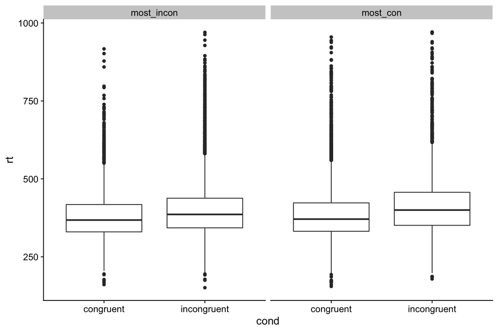

```r
ggplot(flanker, aes(x=cond, y=rt)) + geom_boxplot() + facet_wrap(~block) + theme_cowplot()
```

```r
#missed trials
#flanker %>% filter(is.na(rt))
```

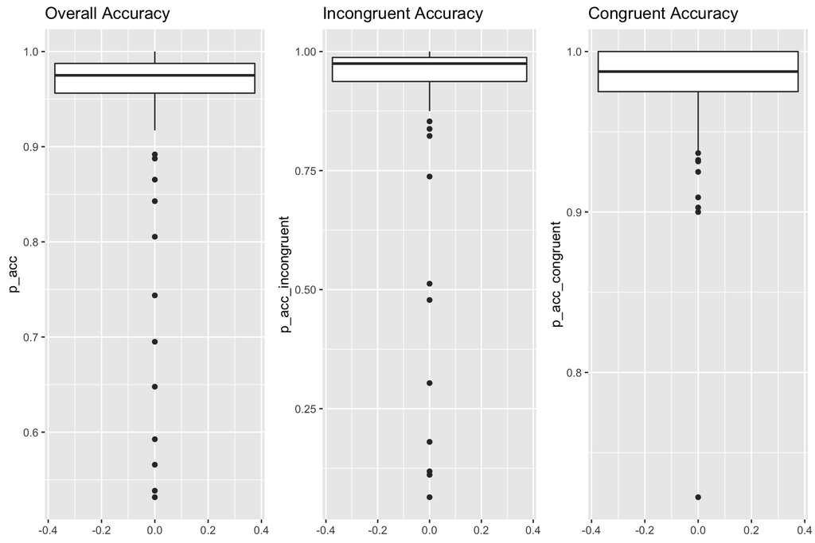

```r
accuracies <- flanker %>% group_by(id, cond) %>%
  summarise(nacc=sum(correct==1, na.rm=T), nerr=sum(correct==0, na.rm=T)) %>%
  pivot_wider(names_from="cond", values_from=c("nerr", "nacc")) %>%
  mutate(
    p_acc=(nacc_congruent + nacc_incongruent)/(nacc_congruent + nacc_incongruent + nerr_congruent + nerr_incongruent),
    p_acc_congruent=(nacc_congruent)/(nacc_congruent + nerr_congruent),
    p_acc_incongruent=(nacc_incongruent)/(nacc_incongruent + nerr_incongruent)
  )

g1 <- ggplot(accuracies, aes(y=p_acc)) + geom_boxplot() + ggtitle("Overall Accuracy")
g2 <- ggplot(accuracies, aes(y=p_acc_incongruent)) + geom_boxplot() + ggtitle("Incongruent Accuracy")
g3 <- ggplot(accuracies, aes(y=p_acc_congruent)) + geom_boxplot() + ggtitle("Congruent Accuracy")
plot_grid(g1, g2, g3, nrow=1)
```

```r
#exclusion subjects from dissertation
accuracies %>% filter(id %in% c(7, 14, 36, 38, 47, 55, 62, 83))
```

```
## # A tibble: 8 x 8
## # Groups:   id [8]
##      id nerr_congruent nerr_incongruent nacc_congruent nacc_incongruent p_acc p_acc_congruent p_acc_incongruent
##   <dbl>          <int>            <int>          <int>            <int> <dbl>           <dbl>             <dbl>
## 1     7              2               64             78                8 0.566           0.975            0.111
## 2    14              1               55             79               24 0.648           0.988            0.304
## 3    36             20                9             52               68 0.805           0.722            0.883
## 4    38              2               39             78               41 0.744           0.975            0.512
## 5    47              5               50             69               11 0.593           0.932            0.180
## 6    55              1               73             79                5 0.532           0.988            0.0641
## 7    62              7               36             65               33 0.695           0.903            0.478
## 8    83              5               67             75                9 0.538           0.938            0.118
```

```r
#kable(accuracies %>% filter(n_acc < .))
```

## Subject exclusions

Looking over exclusions from dissertation, I might advocate a more conservative approach (keep more data). But there are clearly folks who are systematically wrong on incongruent (< 50%), suggesting that they did not understand the task.

### Exclusion coding

Generate a column called exclude with the following scheme:

- 0: a good subject, no concerns
- 1: a subject with minor problems that we should try to salvage
- 2: a suspicious subject whose behavior is questionable, but not obviously bad
- 3: a subject who should certainly be excluded.

Following this scheme, here are the combined recommendations of Nate and Michael. Here, I’ve built on the code above, plus Nate’s FlankerPreprocessing R Markdown.

#### 3: obviously bad subjects

Systematically wrong on incongruent trials. Suggests that they simply didn’t understand the task.

- 7: 11.1% accuracy on incongruent; 97.5% accuracy congruent
- 47: 18.0% accuracy on incongruent; 93.2% accuracy congruent
- 55: 6.4% accuracy on incongruent; 98.8% congruent
- 83: 11.8% accuracy on incongruent; 93.8% congruent

#### 2: probably bad

At chance, or somewhat below, on incongruent trials

- 14: 30.4% accuracy on incongruent; 98.8% accuracy congruent
- 38: 51.2% accuracy on incongruent; 97.5% congruent
- 62: 47.8% accuracy on incongruent; 90.3% congruent

#### 1: questionable, but not clearly flawed

- 36: 88.3% accuracy on incongruent; 72.2% accuracy congruent
- 15: mean RT > 3SDs above sample harmonic mean (per Nate)
- 111: mean RT > 3SDs above sample harmonic mean (per Nate)
- 90: strange behavior on incon (per Nate)?

I’d say we’re justified in dropping these folks given that both 15 and 111 are greater than 3SDs above the mean RT for the crossed stimulus type and block type cells (even after winsorizing). 90 is whacky bc they are so far out on the incong-incong combination. I’d say this warrants us booting them in order to be conservative.

```r
flanker <- flanker %>% mutate(
  exclude=dplyr::recode(id,
                 `7`  = 3, `47` = 3, `55` = 3, `83` = 3,
                 `14` = 2, `38` = 2, `62` = 2,
                 `36` = 1, `15` = 1, `111` = 1, `90` = 1,
                 .default = 0
                 ))
length(unique(flanker$id))
```

```
## [1] 111
```

## RT problems

Following Nate’s document, let’s treat RTs < 250ms as implausible. I started out with < 200ms as the target, but then in looking at transformed RTs, keeping the 200-250ms range led to a slightly long left tail in the distribution after the 1/RT transformation. I solved this by trimming the bottom 1% of RTs by condition and block (at group level), but ironically, this specifically targeted RTs between 201ms and 250ms. So, we land on the 250ms threshold either way we slice things, and the data are beautifully normal under a 1/RT transformation with this threshold.

Number of trials with RTs < 250.

```r
nrow(flanker %>% filter(rt < 250))
```

```
## [1] 235
```

This is about 1.3% of the data, which is a very minor loss.

Set accuracy and RT to NA when RT < 250ms.

```r
flanker <- flanker %>% mutate(rt=if_else(rt < 250, NA_real_, rt), correct=if_else(rt < 250, NA_real_, correct))
#flanker <- flanker %>% filter(!is.na(rt)) #drop rows with missing RTs
```

# Getting the distribution of RTs right

One question is whether we should be modeling $log(RT)$ or just $RT$. Following Ratcliff, a log-normal assumption on RTs is pretty reasonable. What does the density look like for each?

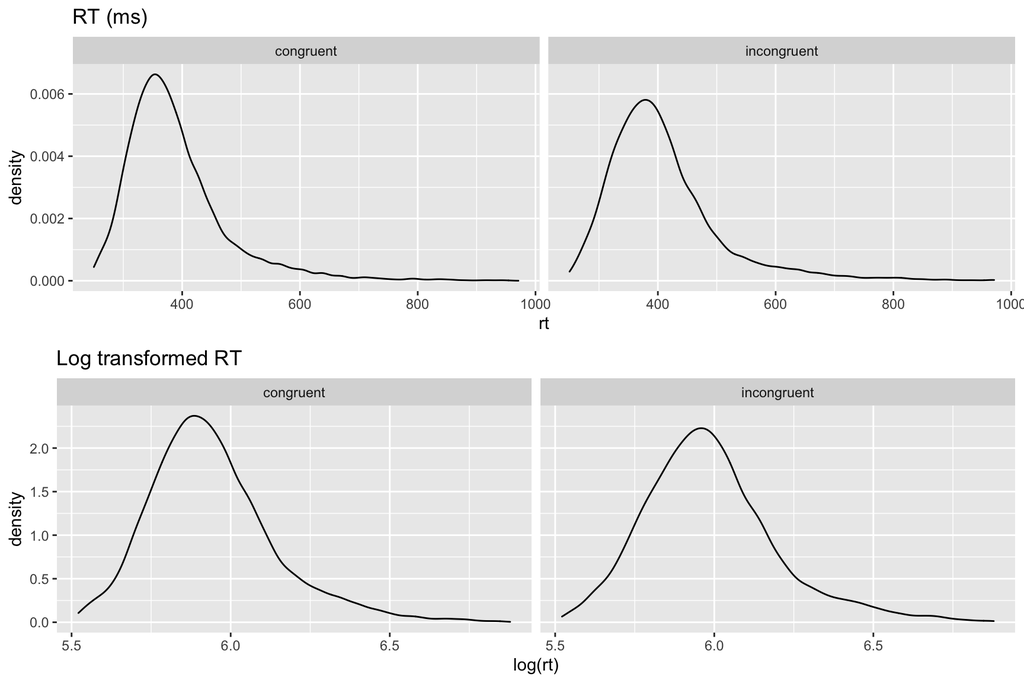

```r
g1 <- ggplot(flanker, aes(x=rt)) + geom_density() + facet_wrap(~cond) + ggtitle("RT (ms)")
g2 <- ggplot(flanker, aes(x=log(rt))) + geom_density() + facet_wrap(~cond) + ggtitle("Log transformed RT")
plot_grid(g1, g2, nrow=2)
```

```r
cat("Skewness of raw RT by block\n")
```

```
## Skewness of raw RT by block
```

```r
tapply(flanker$rt, flanker$cond, moments::skewness, na.rm=T)
```

```
##   congruent incongruent
##        1.84        1.73
```

```r
cat("Skewness of log(RT) by block\n")
```

```
## Skewness of log(RT) by block
```

```r
tapply(log(flanker$rt), flanker$cond, moments::skewness, na.rm=T)
```

```
##   congruent incongruent
##       0.923       0.820
```

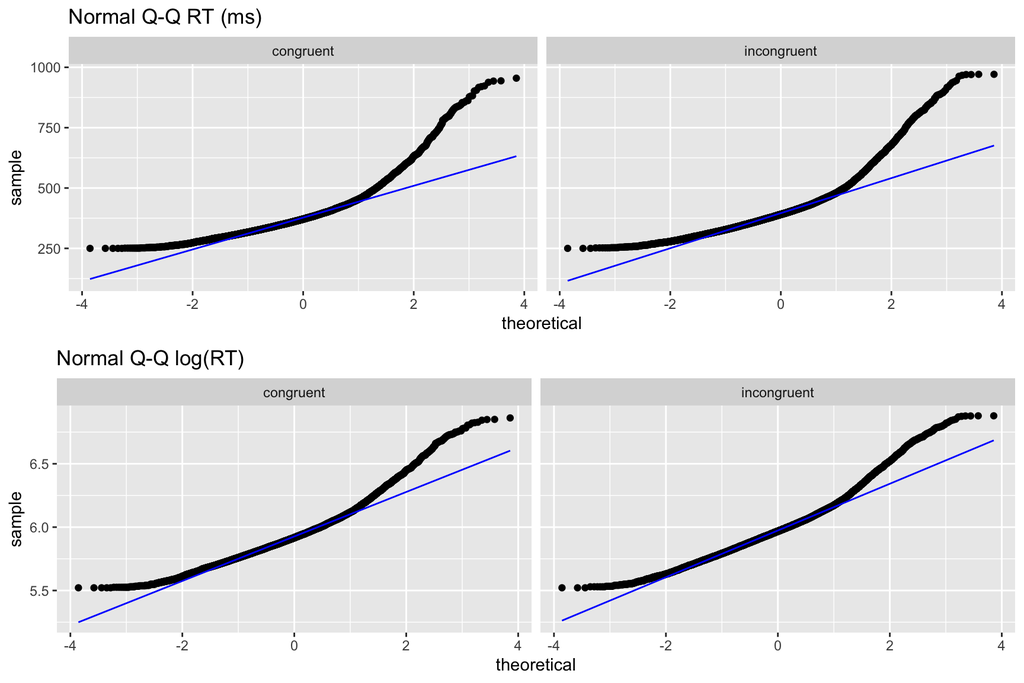

```r
g1 <- ggplot(flanker, aes(sample=rt)) + stat_qq(distribution=qnorm) + stat_qq_line(color="blue") +
  facet_wrap(~cond) + ggtitle("Normal Q-Q RT (ms)")
g2 <- ggplot(flanker, aes(sample=log(rt))) + stat_qq(distribution=qnorm) + stat_qq_line(color="blue") +
  facet_wrap(~cond) + ggtitle("Normal Q-Q log(RT)")
plot_grid(g1, g2, nrow=2)
```

Looks like modeling $log(RT)$ is closer to a standard Gaussian-distributed, though there is still a small positive tail that deviates from normality.

What about inverse transform?

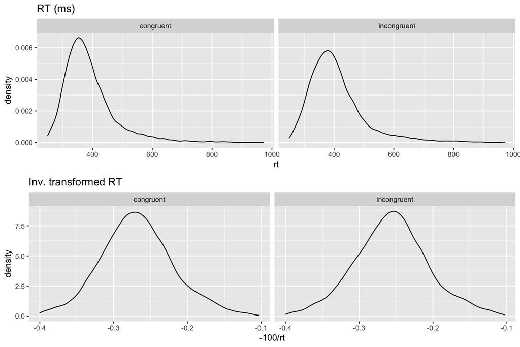

```r
g1 <- ggplot(flanker, aes(x=rt)) + geom_density() + facet_wrap(~cond) + ggtitle("RT (ms)")
g2 <- ggplot(flanker, aes(x=-100/rt)) + geom_density() + facet_wrap(~cond) + ggtitle("Inv. transformed RT")
plot_grid(g1, g2, nrow=2)
```

```r
cat("Skewness of inverse RT by block\n")
```

```
## Skewness of inverse RT by block
```

```r
tapply(-100/flanker$rt, flanker$cond, moments::skewness, na.rm=T)
```

```
##   congruent incongruent
##      0.2224      0.0984
```

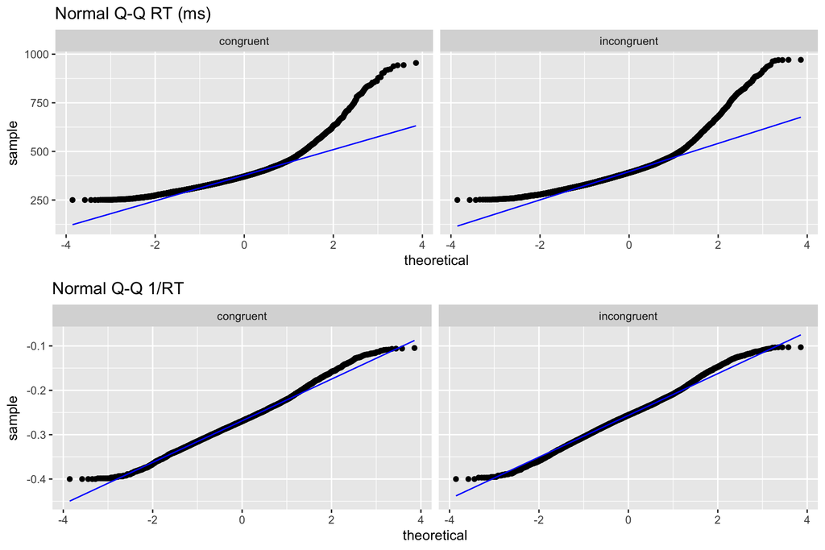

```r
g1 <- ggplot(flanker, aes(sample=rt)) + stat_qq(distribution=qnorm) + stat_qq_line(color="blue") +
  facet_wrap(~cond) + ggtitle("Normal Q-Q RT (ms)")
g2 <- ggplot(flanker, aes(sample=-100/rt)) + stat_qq(distribution=qnorm) + stat_qq_line(color="blue") +
  facet_wrap(~cond) + ggtitle("Normal Q-Q 1/RT")
plot_grid(g1, g2, nrow=2)
```

At 200ms, Inverse transform works somewhat better, though it suppresses a few more RTs at the bottom end vis-a-vis a normal distribution.

At 250ms, however, which is what is plotted above, everything looks good enough!

```r
#What about Winsorizing the top 1% of log-transformed RTs by condition and block?
flanker <- flanker %>% group_by(cond, block) %>%
  mutate(
    rt_log=log10(rt),
    rt_log_winsor=DescTools::Winsorize(rt_log, probs=c(0, .99), na.rm = T),
  ) %>%
  ungroup() %>% group_by(id, cond, block) %>% #use per-subject condition and block RT quantiles to trim
  mutate(
    rt_inv_trim=if_else(rt_inv < quantile(rt_inv, 0.01, na.rm=T), NA_real_, rt_inv), #rt_inv > quantile(rt_inv, 0.99) |
    rt_trim=if_else(rt > quantile(rt, 0.99, na.rm=T), NA_real_, rt),
    rt_log_trim=if_else(rt_log > quantile(rt_log, 0.99, na.rm=T), NA_real_, rt_log)
  ) %>% ungroup() %>%
  group_by(cond, block) %>% #use overall condition and block RT quantiles to trim
  mutate(
    rt_inv_trim_grp=if_else(rt_inv < quantile(rt_inv, 0.01, na.rm=T), NA_real_, rt_inv), #rt_inv > quantile(rt_inv, 0.99) |
    rt_trim_grp=if_else(rt > quantile(rt, 0.99, na.rm=T), NA_real_, rt),
    rt_log_trim_grp=if_else(rt_log > quantile(rt_log, 0.99, na.rm=T), NA_real_, rt_log)
  ) %>% ungroup()


g1 <- ggplot(flanker, aes(sample=rt_log_winsor)) + stat_qq(distribution=qnorm) + stat_qq_line(color="blue") +
  facet_wrap(~cond) + ggtitle("Normal Q-Q Winsorize log(RT)")
g2 <- ggplot(flanker, aes(sample=rt_log_trim)) + stat_qq(distribution=qnorm) + stat_qq_line(color="blue") +
  facet_wrap(~cond) + ggtitle("Normal Q-Q Trimmed log(RT)")
g3 <- ggplot(flanker, aes(sample=rt_inv_trim)) + stat_qq(distribution=qnorm) + stat_qq_line(color="blue") +
  facet_wrap(~cond) + ggtitle("Normal Q-Q Trimmed 1/RT")
g4 <- ggplot(flanker, aes(sample=rt_log_trim_grp)) + stat_qq(distribution=qnorm) + stat_qq_line(color="blue") +
  facet_wrap(~cond) + ggtitle("Normal Q-Q Group-Trimmed log(RT)")
g5 <- ggplot(flanker, aes(sample=rt_inv_trim_grp)) + stat_qq(distribution=qnorm) + stat_qq_line(color="blue") +
  facet_wrap(~cond) + ggtitle("Normal Q-Q Group-Trimmed 1/RT")
g6 <- ggplot(flanker, aes(sample=rt_inv)) + stat_qq(distribution=qnorm) + stat_qq_line(color="blue") +
  facet_wrap(~cond) + ggtitle("Normal Q-Q 1/RT")

plot_grid(g1, g2, g3, g4, g5, g6, nrow=3)

#the problem with per-subject trimming is that many plausible values are removed since they are unlikely compared to the subject's distribution
flanker %>% filter(is.na(rt_inv_trim)) %>% pull(rt) %>% hist(main="RTs dropped by subject-specific trim")
flanker %>% filter(is.na(rt_inv_trim_grp)) %>% pull(rt) %>% hist(main="RTs dropped by group trim")
flanker %>% filter(is.na(rt_inv_trim_grp)) %>% nrow()
flanker %>% filter(is.na(rt)) %>% nrow()
```

For the moment, the inverse-transformed RT shows the most promise, which matches Ratcliff (1993) recommendations.

# Frequentist MLMs using maximum likelihood and no explicit temporal covariance

Some useful resources:

https://rpsychologist.com/r-guide-longitudinal-lme-lmer

https://wiekvoet.blogspot.com/2013/09/mixed-models-influence-in-heterogeneous.html

https://quantdev.ssri.psu.edu/sites/qdev/files/ILD_Ch06_2017_MLMwithHeterogeneousVariance.html

https://m-clark.github.io/mixed-models-with-R/

(information about blocked variance components and interpreting lme output)

https://rstudio-pubs-static.s3.amazonaws.com/234821_71b392d30fe741e8afe32896a7446226.html

https://bookdown.org/content/3890/

https://mjskay.github.io/tidybayes/articles/tidybayes.html

https://fukamilab.github.io/BIO202/03-C-heterogeneity.html

https://www.statforbiology.com/2019/stat_nlmm_designconstraints/

http://www.dwoll.de/rexrepos/posts/anovaMixed.html

https://lindeloev.github.io/shiny-rt/

https://www.flutterbys.com.au/stats/tut/tut8.3b.html

N.B. We are now analyzing only RTs on correct trials, not all RTs.

```r
flanker <- flanker %>% filter(exclude < 3) #keep most subjects, exclude horrid ones
save(flanker, file="../../Data/preprocessed/flanker_for_traits.RData")

#filter to correct only.
flanker <- flanker %>% filter(correct==1)
```

## m0: random intercept of subject, experiment conditions only

```r
m0 <- lme(rt_inv ~ cond*block, random = ~ 1 | id,
          na.action = na.exclude,
          data = flanker, method='REML')

summary(m0)
```

```
## Linear mixed-effects model fit by REML
##  Data: flanker
##     AIC   BIC logLik
##   14727 14773  -7357
##
## Random effects:
##  Formula: ~1 | id
##         (Intercept) Residual
## StdDev:         0.3    0.374
##
## Fixed effects: rt_inv ~ cond * block
##                                Value Std.Error    DF t-value p-value
## (Intercept)                   -2.702   0.02998 16145   -90.1  0.0000
## condincongruent                0.115   0.00901 16145    12.7  0.0000
## blockmost_con                  0.024   0.00897 16145     2.7  0.0066
## condincongruent:blockmost_con  0.049   0.01284 16145     3.8  0.0001
##  Correlation:
##                               (Intr) cndncn blckm_
## condincongruent               -0.208
## blockmost_con                 -0.209  0.695
## condincongruent:blockmost_con  0.146 -0.701 -0.699
##
## Standardized Within-Group Residuals:
##     Min      Q1     Med      Q3     Max
## -4.5809 -0.5999  0.0185  0.5964  4.2223
##
## Number of Observations: 16255
## Number of Groups: 107
```

```r
anova(m0)
```

```
##             numDF denDF F-value p-value
## (Intercept)     1 16145    8104  <.0001
## cond            1 16145     413  <.0001
## block           1 16145      57  <.0001
## cond:block      1 16145      15   1e-04
```

```r
car::Anova(m0, type=3)
```

```
## Analysis of Deviance Table (Type III tests)
##
## Response: rt_inv
##               Chisq Df Pr(>Chisq)
## (Intercept) 8123.63  1    < 2e-16 ***
## cond         162.15  1    < 2e-16 ***
## block          7.38  1    0.00658 **
## cond:block    14.82  1    0.00012 ***
## ---
## Signif. codes:  0 '***' 0.001 '**' 0.01 '*' 0.05 '.' 0.1 ' ' 1
```

## m1: random intercept of subject, CS structure wrt trial

starting point in ML: random intercept of subject, compount symmetry residual correlation structure wrt trial

```r
m1 <- lme(rt_inv ~ trial_z + cond*block, random = ~ 1 | id,
          correlation=corCompSymm(form=~trial|id), na.action = na.exclude,
          data = flanker, method='ML')

summary(m1)
```

```
## Linear mixed-effects model fit by maximum likelihood
##  Data: flanker
##     AIC   BIC logLik
##   14630 14692  -7307
##
## Random effects:
##  Formula: ~1 | id
##         (Intercept) Residual
## StdDev:       0.299    0.374
##
## Correlation Structure: Compound symmetry
##  Formula: ~trial | id
##  Parameter estimate(s):
## Rho
##   0
## Fixed effects: rt_inv ~ trial_z + cond * block
##                                Value Std.Error    DF t-value p-value
## (Intercept)                   -2.702   0.02985 16144   -90.5  0.0000
## trial_z                       -0.025   0.00293 16144    -8.5  0.0000
## condincongruent                0.115   0.00899 16144    12.8  0.0000
## blockmost_con                  0.024   0.00896 16144     2.7  0.0073
## condincongruent:blockmost_con  0.050   0.01281 16144     3.9  0.0001
##  Correlation:
##                               (Intr) tril_z cndncn blckm_
## trial_z                        0.000
## condincongruent               -0.208 -0.001
## blockmost_con                 -0.209  0.005  0.695
## condincongruent:blockmost_con  0.146 -0.001 -0.701 -0.699
##
## Standardized Within-Group Residuals:
##     Min      Q1     Med      Q3     Max
## -4.6860 -0.5970  0.0169  0.5921  4.3067
##
## Number of Observations: 16255
## Number of Groups: 107
```

```r
emmeans(m1, ~cond | block)
```

```
## block = most_incon:
##  cond        emmean     SE  df lower.CL upper.CL
##  congruent    -2.70 0.0299 106    -2.76    -2.64
##  incongruent  -2.59 0.0293 106    -2.65    -2.53
##
## block = most_con:
##  cond        emmean     SE  df lower.CL upper.CL
##  congruent    -2.68 0.0293 106    -2.74    -2.62
##  incongruent  -2.51 0.0299 106    -2.57    -2.45
##
## Degrees-of-freedom method: containment
## Confidence level used: 0.95
```

## m2: simple random intercept model

Compound symmetry is already captured above by a simple variance component (G-side), which is why the CS correlation is zero in a model that has both.

This is discussed here: https://m-clark.github.io/mixed-models-with-R/extensions.html

Go back to a simple random intercept model.

```r
m2 <- lme(rt_inv ~ trial_z + cond*block, random = ~ 1 | id,
          na.action = na.exclude,
          data = flanker, method='ML', control = lmeControl(opt="optim"))

summary(m2)
```

```
## Linear mixed-effects model fit by maximum likelihood
##  Data: flanker
##     AIC   BIC logLik
##   14628 14682  -7307
##
## Random effects:
##  Formula: ~1 | id
##         (Intercept) Residual
## StdDev:       0.299    0.374
##
## Fixed effects: rt_inv ~ trial_z + cond * block
##                                Value Std.Error    DF t-value p-value
## (Intercept)                   -2.702   0.02985 16144   -90.5  0.0000
## trial_z                       -0.025   0.00293 16144    -8.5  0.0000
## condincongruent                0.115   0.00899 16144    12.8  0.0000
## blockmost_con                  0.024   0.00896 16144     2.7  0.0073
## condincongruent:blockmost_con  0.050   0.01281 16144     3.9  0.0001
##  Correlation:
##                               (Intr) tril_z cndncn blckm_
## trial_z                        0.000
## condincongruent               -0.208 -0.001
## blockmost_con                 -0.209  0.005  0.695
## condincongruent:blockmost_con  0.146 -0.001 -0.701 -0.699
##
## Standardized Within-Group Residuals:
##     Min      Q1     Med      Q3     Max
## -4.6860 -0.5970  0.0169  0.5921  4.3067
##
## Number of Observations: 16255
## Number of Groups: 107
```

```r
anova(m1, m2)
```

```
##    Model df   AIC   BIC logLik   Test L.Ratio p-value
## m1     1  8 14630 14692  -7307
## m2     2  7 14628 14682  -7307 1 vs 2       0       1
```

```r
emmeans(m2, ~cond | block)
```

```
## block = most_incon:
##  cond        emmean     SE  df lower.CL upper.CL
##  congruent    -2.70 0.0299 106    -2.76    -2.64
##  incongruent  -2.59 0.0293 106    -2.65    -2.53
##
## block = most_con:
##  cond        emmean     SE  df lower.CL upper.CL
##  congruent    -2.68 0.0293 106    -2.74    -2.62
##  incongruent  -2.51 0.0299 106    -2.57    -2.45
##
## Degrees-of-freedom method: containment
## Confidence level used: 0.95
```

```r
#same log likelihood!
cat("LL(m1) - LL(m2)\n")
```

```
## LL(m1) - LL(m2)
```

```r
logLik(m1) - logLik(m2)
```

```
## 'log Lik.' 0 (df=8)
```

## m3: R-side only CS model

Verify that an R-side only compound symmetry model matches variance component random intercept model. Need to use `gls` for this.

```r
#Here's the R-side only model with compound symmetry (no random intercept)
#this should also yield identical fit statistics -- just a reparameterization of the same approach
m3 <- gls(rt_inv ~ trial_z + cond*block, correlation=corCompSymm(form=~trial|id), na.action = na.exclude,
          data = flanker, method='ML')

anova(m2, m3)
```

```
##    Model df   AIC   BIC logLik
## m2     1  7 14628 14682  -7307
## m3     2  7 14628 14682  -7307
```

```r
cat("LL(m3) - LL(m2)\n")
```

```
## LL(m3) - LL(m2)
```

```r
logLik(m3) - logLik(m2)
```

```
## 'log Lik.' 1.16e-10 (df=7)
```

```r
#look at model-predicted residual correlation structure

#R.a <- getVarCov(dental.lme.a,type="conditional",individual=1)
rcov <- getVarCov(m3, type="conditional", individual=1) #covariance matrix
rcorr <- cov2cor(getVarCov(m3, type="conditional",individual=1)) #residual correlation matrix for subj 1

#V_i <- getVarCov(m3, type="marginal", individual=1)
```

*Conclusion*: Confirmed that m1, m2, and m3 are isomorphic with each other. The conceptually simplest model is m2, the random intercept only model. Use this as the benchmark for increasingly complex models below

## m4: random intercept of subject, block nested within subject

```r
m4 <- lme(rt_inv ~ trial_z + cond*block, random=~1|id/block,
          na.action = na.exclude,
          data = flanker, method='ML')

summary(m4)
```

```
## Linear mixed-effects model fit by maximum likelihood
##  Data: flanker
##     AIC   BIC logLik
##   14500 14562  -7242
##
## Random effects:
##  Formula: ~1 | id
##         (Intercept)
## StdDev:       0.296
##
##  Formula: ~1 | block %in% id
##         (Intercept) Residual
## StdDev:      0.0667    0.371
##
## Fixed effects: rt_inv ~ trial_z + cond * block
##                                Value Std.Error    DF t-value p-value
## (Intercept)                   -2.702   0.03022 16038   -89.4  0.0000
## trial_z                       -0.025   0.00291 16038    -8.6  0.0000
## condincongruent                0.115   0.00893 16038    12.9  0.0000
## blockmost_con                  0.024   0.01273   106     1.9  0.0638
## condincongruent:blockmost_con  0.049   0.01272 16038     3.8  0.0001
##  Correlation:
##                               (Intr) tril_z cndncn blckm_
## trial_z                        0.000
## condincongruent               -0.204 -0.001
## blockmost_con                 -0.251  0.004  0.484
## condincongruent:blockmost_con  0.143 -0.002 -0.702 -0.487
##
## Standardized Within-Group Residuals:
##     Min      Q1     Med      Q3     Max
## -4.6539 -0.5964  0.0167  0.5893  4.4180
##
## Number of Observations: 16255
## Number of Groups:
##            id block %in% id
##           107           214
```

```r
#getVarCov(m4, "random.effects")

anova(m2, m4)
```

```
##    Model df   AIC   BIC logLik   Test L.Ratio p-value
## m2     1  7 14628 14682  -7307
## m4     2  8 14500 14562  -7242 1 vs 2     130  <.0001
```

Allowing for a block within id variance component improves fit considerably.

## m5: Random intercept per block (heterogeneous L2 intercept)

Alternatively, we could consider whether we need separate variance components for the mostly congruent and mostly incongruent blocks.

This is a heterogeneous intercept per block approach in lme, which allows the G-side part of the model (variance components) to be uniquely estimated per block, while keeping the L1 residual $\sigma^2_e$ homogeneous.

```r
#allows for variance heterogeneity between mostly congruent and mostly incongruent blocks
#this generates a diagonal G-side matrix where each block has a different SD that controls
#between-person variation in the random intercept. So now, each subject has an EBLUP
#for the mostly congruent and mostly incongruent block.

m5 <- lme(rt_inv ~ trial_z + cond*block,
          random=list(id=pdDiag(~block)),
          na.action = na.exclude,
          data = flanker, method='ML')

summary(m5)
```

```
## Linear mixed-effects model fit by maximum likelihood
##  Data: flanker
##     AIC   BIC logLik
##   14502 14563  -7243
##
## Random effects:
##  Formula: ~block | id
##  Structure: Diagonal
##         (Intercept) blockmost_con Residual
## StdDev:         0.3        0.0935    0.371
##
## Fixed effects: rt_inv ~ trial_z + cond * block
##                                Value Std.Error    DF t-value p-value
## (Intercept)                   -2.702   0.02995 16144   -90.2  0.0000
## trial_z                       -0.025   0.00291 16144    -8.6  0.0000
## condincongruent                0.115   0.00893 16144    12.9  0.0000
## blockmost_con                  0.024   0.01267 16144     1.9  0.0602
## condincongruent:blockmost_con  0.049   0.01272 16144     3.8  0.0001
##  Correlation:
##                               (Intr) tril_z cndncn blckm_
## trial_z                        0.000
## condincongruent               -0.206 -0.001
## blockmost_con                 -0.145  0.004  0.487
## condincongruent:blockmost_con  0.145 -0.002 -0.702 -0.490
##
## Standardized Within-Group Residuals:
##     Min      Q1     Med      Q3     Max
## -4.6614 -0.5963  0.0161  0.5884  4.4215
##
## Number of Observations: 16255
## Number of Groups: 107
```

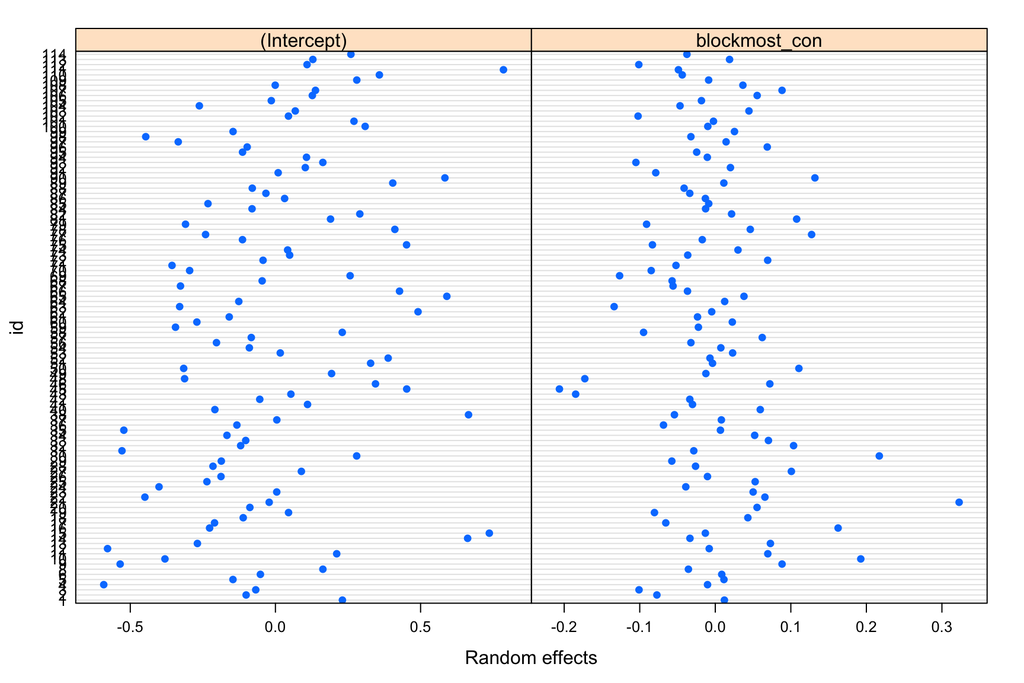

```r
#cor(ranef(m5)) #clean: ~0
vv <- ranef(m5)
plot(vv)
```

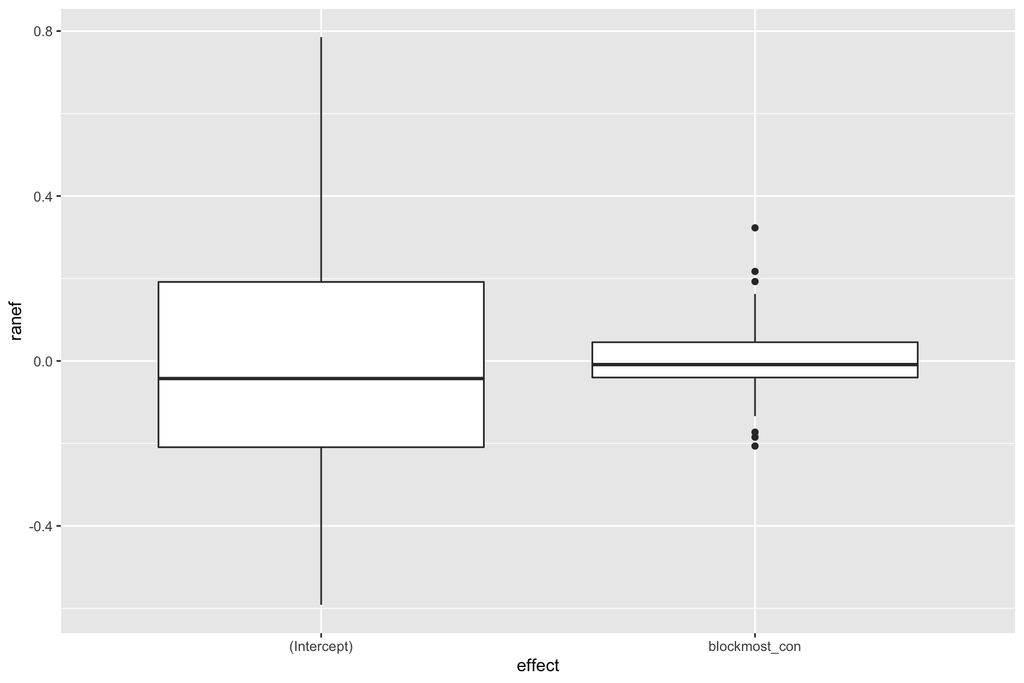

```r
vv %>% pivot_longer(cols = everything()) %>% ggplot(aes(x=name, y=value)) + geom_boxplot() + labs(y="ranef", x="effect")
```

```r
#VarCorr(m5)

#reconstruct subject-specific variance estimates for each condition using the regression parameterization
estimated_ranef <- data.frame(
  mostly_congruent = vv[,"(Intercept)"] + vv[,"blockmost_con"],
  mostly_incongruent = vv[,"(Intercept)"] #incongruent is reference condition
)

#N.B. The addition of -1 in the pdDiag call appears to remove the intercept from the L2 parameterization,
#resulting in individual estimates for each block. Although this seems more intuitive and would be
#closer to a no-intercept model, the LL is way worse than m5 above. I don't know why, but I suspect it is
#because the two random effects (mostly congruent and mostly incongruent) become intractably correlated.
m5b <- lme(rt_inv ~ trial_z + cond*block,
          random=list(id=pdDiag(~block-1)),
          na.action = na.exclude,
          data = flanker, method='ML')

#cor(ranef(m5b)) #ugly: ~.94

#equivalent model in glmmTMB
m5_glmmTMB <- glmmTMB(rt_inv ~ trial_z + cond*block + diag(1 + block|id),
                na.action = na.exclude,
                data = flanker, REML = FALSE)

# AICtab(m5, m5_glmmTMB)
```

Here, the SD of the individual differences in the intercept for the mostly incongruent block is labeled (Intercept) because that is the reference level for `flanker$block`. And the SD of random intercept for the mostly congruent block is the `(Intercept)` + the `blockmost_con` components. Thus, the variance of the mostly congruent condition is somewhat larger than for mostly incongruent.

```r
sapply(estimated_ranef, sd)
```

```
##   mostly_congruent mostly_incongruent
##              0.305              0.299
```

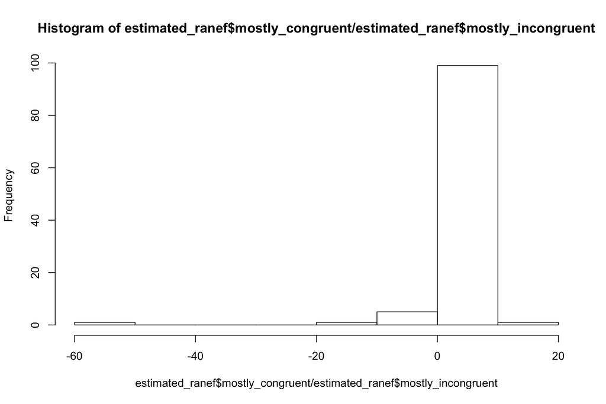

```r
hist(estimated_ranef$mostly_congruent / estimated_ranef$mostly_incongruent) # one person looks a bit funky...
```

```r
#pdf("resid_test.pdf", width=12, height=20)
#plot(m5,form=resid(., type = "p") ~fitted(.) | id, idLabels=~id)
#plot(ranef(m5))
#dev.off()
```

One conceptual question is whether that variation is driven by the trial condition (incongruent versus congruent), not the block type. That is, perhaps incongruent trials are just more variable in RT than congruent ones, regardless of block. But let’s table that and just look at variants of heterogeneous variance by block type.

## m6: allow for heterogeneous L1 variance by block

Instead of allowing the L2 estimates of random intercept to vary by block, we could allow for a heterogeneous L1 residual variance by block. Since we do not have any formal L2 random effects (e.g., intercept), estimate the model with `gls`. Note that this model is conceptually rather flawed because it does not capture within-subject correlation. That is, `id` does not appear in any part of the specification

```r
m6 <- gls(rt_inv ~ trial_z + cond*block,
          weights=varIdent(form=~1|block),
          na.action = na.exclude,
          data = flanker, method='ML')

summary(m6)
```

```
## Generalized least squares fit by maximum likelihood
##   Model: rt_inv ~ trial_z + cond * block
##   Data: flanker
##     AIC   BIC logLik
##   21971 22025 -10979
##
## Variance function:
##  Structure: Different standard deviations per stratum
##  Formula: ~1 | block
##  Parameter estimates:
##   most_con most_incon
##      1.000      0.955
##
## Coefficients:
##                                Value Std.Error t-value p-value
## (Intercept)                   -2.700   0.00930  -290.4  0.0000
## trial_z                       -0.024   0.00379    -6.3  0.0000
## condincongruent                0.108   0.01117     9.7  0.0000
## blockmost_con                  0.026   0.01129     2.3  0.0224
## condincongruent:blockmost_con  0.049   0.01631     3.0  0.0028
##
##  Correlation:
##                               (Intr) tril_z cndncn blckm_
## trial_z                        0.000
## condincongruent               -0.832  0.000
## blockmost_con                 -0.823  0.005  0.685
## condincongruent:blockmost_con  0.570 -0.002 -0.685 -0.693
##
## Standardized residuals:
##      Min       Q1      Med       Q3      Max
## -3.05060 -0.64757 -0.00543  0.62053  3.45200
##
## Residual standard error: 0.487
## Degrees of freedom: 16255 total; 16250 residual
```

### m7: Heterogeneous L1 variance, add homogeneous random intercept at L2

We can allow for block-specific L1 residual variance and a single L2 (here, intercept) variance component (not block-specific) by combining `weights` and `random` as follows:

```r
#https://m-clark.github.io/mixed-models-with-R/extensions.html

#heterogeneous L1 resid var, homogeneous L2 intercept
m7 <- lme(rt_inv ~ trial_z + cond*block,
          weights=varIdent(form=~1|block),
          random=~1|id,
          na.action = na.exclude,
          data = flanker, method='ML')

summary(m7)
```

```
## Linear mixed-effects model fit by maximum likelihood
##  Data: flanker
##     AIC   BIC logLik
##   14595 14657  -7290
##
## Random effects:
##  Formula: ~1 | id
##         (Intercept) Residual
## StdDev:       0.299    0.386
##
## Variance function:
##  Structure: Different standard deviations per stratum
##  Formula: ~1 | block
##  Parameter estimates:
##   most_con most_incon
##      1.000      0.935
## Fixed effects: rt_inv ~ trial_z + cond * block
##                                Value Std.Error    DF t-value p-value
## (Intercept)                   -2.702   0.02979 16144   -90.7  0.0000
## trial_z                       -0.025   0.00300 16144    -8.3  0.0000
## condincongruent                0.115   0.00869 16144    13.2  0.0000
## blockmost_con                  0.024   0.00884 16144     2.7  0.0065
## condincongruent:blockmost_con  0.050   0.01281 16144     3.9  0.0001
##  Correlation:
##                               (Intr) tril_z cndncn blckm_
## trial_z                        0.000
## condincongruent               -0.202 -0.001
## blockmost_con                 -0.198  0.005  0.680
## condincongruent:blockmost_con  0.137 -0.002 -0.677 -0.690
##
## Standardized Within-Group Residuals:
##     Min      Q1     Med      Q3     Max
## -4.5430 -0.5985  0.0159  0.5942  4.2174
##
## Number of Observations: 16255
## Number of Groups: 107
```

## m8: Heterogeneous L1 residual variance and L2 random intercept, both estimated per block

```r
#this model allows for heterogeneity in the L1 residuals by block, as well as the L2 random effects by block
m8 <- lme(rt_inv ~ trial_z + cond*block,
          weights=varIdent(form=~1|block),
          random=list(id = pdDiag(~block)),
          na.action = na.exclude,
          data = flanker, method='ML')

summary(m8)
```

```
## Linear mixed-effects model fit by maximum likelihood
##  Data: flanker
##     AIC   BIC logLik
##   14469 14538  -7225
##
## Random effects:
##  Formula: ~block | id
##  Structure: Diagonal
##         (Intercept) blockmost_con Residual
## StdDev:         0.3        0.0935    0.383
##
## Variance function:
##  Structure: Different standard deviations per stratum
##  Formula: ~1 | block
##  Parameter estimates:
##   most_con most_incon
##      1.000      0.936
## Fixed effects: rt_inv ~ trial_z + cond * block
##                                Value Std.Error    DF t-value p-value
## (Intercept)                   -2.702   0.02992 16144   -90.3  0.0000
## trial_z                       -0.025   0.00298 16144    -8.4  0.0000
## condincongruent                0.115   0.00863 16144    13.4  0.0000
## blockmost_con                  0.024   0.01260 16144     1.9  0.0586
## condincongruent:blockmost_con  0.049   0.01272 16144     3.8  0.0001
##  Correlation:
##                               (Intr) tril_z cndncn blckm_
## trial_z                        0.000
## condincongruent               -0.199 -0.001
## blockmost_con                 -0.137  0.004  0.473
## condincongruent:blockmost_con  0.135 -0.002 -0.678 -0.480
##
## Standardized Within-Group Residuals:
##     Min      Q1     Med      Q3     Max
## -4.5177 -0.5967  0.0163  0.5909  4.2814
##
## Number of Observations: 16255
## Number of Groups: 107
```

```r
AICtab(m2, m4, m5, m6, m7, m8, sort=TRUE, delta=TRUE, weights=TRUE, logLik=TRUE, base=TRUE)
```

```
##    logLik   AIC      dLogLik  dAIC     df weight
## m8  -7225.4  14468.9   3753.1      0.0 9  1
## m4  -7242.1  14500.2   3736.5     31.3 8  <0.001
## m5  -7242.8  14501.6   3735.8     32.7 8  <0.001
## m7  -7289.6  14595.2   3689.0    126.3 8  <0.001
## m2  -7307.0  14628.1   3671.5    159.2 7  <0.001
## m6 -10978.6  21971.2      0.0   7502.3 7  <0.001
```

As Clark notes, the parameterization of the intercept variances by block is funky, with one serving as a reference condition, variance = 1.0.

The glmmTMB package provides a more intuitive parameterization.

## m8a: use nesting structure, not pdDiag for per-block random intercept

```r
#this model allows for heterogeneity in the L1 residuals by block, as well as the L2 random effects by block
m8a <- lme(rt_inv ~ trial_z + cond*block,
          weights=varIdent(form=~1|block),
          random=~1|id/block,
          na.action = na.exclude,
          data = flanker, method='ML')

summary(m8a)
```

```
## Linear mixed-effects model fit by maximum likelihood
##  Data: flanker
##     AIC   BIC logLik
##   14467 14537  -7225
##
## Random effects:
##  Formula: ~1 | id
##         (Intercept)
## StdDev:       0.296
##
##  Formula: ~1 | block %in% id
##         (Intercept) Residual
## StdDev:      0.0667    0.358
##
## Variance function:
##  Structure: Different standard deviations per stratum
##  Formula: ~1 | block
##  Parameter estimates:
## most_incon   most_con
##       1.00       1.07
## Fixed effects: rt_inv ~ trial_z + cond * block
##                                Value Std.Error    DF t-value p-value
## (Intercept)                   -2.702   0.03016 16038   -89.6  0.0000
## trial_z                       -0.025   0.00298 16038    -8.4  0.0000
## condincongruent                0.115   0.00863 16038    13.4  0.0000
## blockmost_con                  0.024   0.01265   106     1.9  0.0621
## condincongruent:blockmost_con  0.049   0.01272 16038     3.8  0.0001
##  Correlation:
##                               (Intr) tril_z cndncn blckm_
## trial_z                        0.000
## condincongruent               -0.198 -0.001
## blockmost_con                 -0.244  0.004  0.471
## condincongruent:blockmost_con  0.134 -0.002 -0.678 -0.477
##
## Standardized Within-Group Residuals:
##     Min      Q1     Med      Q3     Max
## -4.5097 -0.5969  0.0161  0.5904  4.2775
##
## Number of Observations: 16255
## Number of Groups:
##            id block %in% id
##           107           214
```

```r
AICtab(m2, m4, m5, m6, m7, m8, m8a, sort=TRUE, delta=TRUE, weights=TRUE, logLik=TRUE, base=TRUE)
```

```
##     logLik   AIC      dLogLik  dAIC     df weight
## m8a  -7224.7  14467.4   3753.9      0.0 9  0.68
## m8   -7225.4  14468.9   3753.1      1.5 9  0.32
## m4   -7242.1  14500.2   3736.5     32.8 8  <0.001
## m5   -7242.8  14501.6   3735.8     34.2 8  <0.001
## m7   -7289.6  14595.2   3689.0    127.8 8  <0.001
## m2   -7307.0  14628.1   3671.5    160.7 7  <0.001
## m6  -10978.6  21971.2      0.0   7503.8 7  <0.001
```

## m9: repeat for condition, not block, as key factor

```r
#this model allows for heterogeneity in the L1 residuals by block, as well as the L2 random effects by block
m9 <- lme(rt_inv ~ trial_z + cond*block,
          weights=varIdent(form=~1|cond),
          random=list(id = pdDiag(~cond)),
          na.action = na.exclude,
          data = flanker, method='ML')

summary(m9)
```

```
## Linear mixed-effects model fit by maximum likelihood
##  Data: flanker
##     AIC   BIC logLik
##   14594 14664  -7288
##
## Random effects:
##  Formula: ~cond | id
##  Structure: Diagonal
##         (Intercept) condincongruent Residual
## StdDev:       0.302          0.0633    0.372
##
## Variance function:
##  Structure: Different standard deviations per stratum
##  Formula: ~1 | cond
##  Parameter estimates:
##   congruent incongruent
##           1           1
## Fixed effects: rt_inv ~ trial_z + cond * block
##                                Value Std.Error    DF t-value p-value
## (Intercept)                   -2.702   0.03017 16144   -89.6  0.0000
## trial_z                       -0.025   0.00292 16144    -8.6  0.0000
## condincongruent                0.116   0.01086 16144    10.6  0.0000
## blockmost_con                  0.024   0.00891 16144     2.7  0.0073
## condincongruent:blockmost_con  0.050   0.01276 16144     3.9  0.0001
##  Correlation:
##                               (Intr) tril_z cndncn blckm_
## trial_z                        0.000
## condincongruent               -0.169 -0.001
## blockmost_con                 -0.206  0.005  0.573
## condincongruent:blockmost_con  0.144 -0.002 -0.579 -0.699
##
## Standardized Within-Group Residuals:
##     Min      Q1     Med      Q3     Max
## -4.7062 -0.5965  0.0152  0.5850  4.3167
##
## Number of Observations: 16255
## Number of Groups: 107
```

```r
AICtab(m2, m4, m5, m6, m7, m8, m9, sort=TRUE, delta=TRUE, weights=TRUE, logLik=TRUE, base=TRUE)
```

```
##    logLik   AIC      dLogLik  dAIC     df weight
## m8  -7225.4  14468.9   3753.1      0.0 9  1
## m4  -7242.1  14500.2   3736.5     31.3 8  <0.001
## m5  -7242.8  14501.6   3735.8     32.7 8  <0.001
## m9  -7288.2  14594.4   3690.4    125.5 9  <0.001
## m7  -7289.6  14595.2   3689.0    126.3 8  <0.001
## m2  -7307.0  14628.1   3671.5    159.2 7  <0.001
## m6 -10978.6  21971.2      0.0   7502.3 7  <0.001
```

## m10: random intercept by condition, L1 resid var by block

```r
#this model allows for heterogeneity in the L1 residuals by block, as well as the L2 random effects by block
m10 <- lme(rt_inv ~ trial_z + cond*block,
          weights=varIdent(form=~1|block),
          random=list(id = pdDiag(~cond)),
          na.action = na.exclude,
          data = flanker, method='ML')

summary(m10)
```

```
## Linear mixed-effects model fit by maximum likelihood
##  Data: flanker
##     AIC   BIC logLik
##   14561 14630  -7271
##
## Random effects:
##  Formula: ~cond | id
##  Structure: Diagonal
##         (Intercept) condincongruent Residual
## StdDev:       0.302          0.0623    0.384
##
## Variance function:
##  Structure: Different standard deviations per stratum
##  Formula: ~1 | block
##  Parameter estimates:
##   most_con most_incon
##      1.000      0.936
## Fixed effects: rt_inv ~ trial_z + cond * block
##                                Value Std.Error    DF t-value p-value
## (Intercept)                   -2.702   0.03009 16144   -89.8  0.0000
## trial_z                       -0.025   0.00299 16144    -8.4  0.0000
## condincongruent                0.116   0.01056 16144    10.9  0.0000
## blockmost_con                  0.024   0.00881 16144     2.7  0.0066
## condincongruent:blockmost_con  0.050   0.01277 16144     3.9  0.0001
##  Correlation:
##                               (Intr) tril_z cndncn blckm_
## trial_z                        0.000
## condincongruent               -0.163 -0.001
## blockmost_con                 -0.196  0.005  0.558
## condincongruent:blockmost_con  0.135 -0.002 -0.556 -0.690
##
## Standardized Within-Group Residuals:
##     Min      Q1     Med      Q3     Max
## -4.5637 -0.5980  0.0153  0.5868  4.2744
##
## Number of Observations: 16255
## Number of Groups: 107
```

```r
AICtab(m2, m4, m5, m6, m7, m8, m9, m10, sort=TRUE, delta=TRUE, weights=TRUE, logLik=TRUE, base=TRUE)
```

```
##     logLik   AIC      dLogLik  dAIC     df weight
## m8   -7225.4  14468.9   3753.1      0.0 9  1
## m4   -7242.1  14500.2   3736.5     31.3 8  <0.001
## m5   -7242.8  14501.6   3735.8     32.7 8  <0.001
## m10  -7271.5  14560.9   3707.1     92.0 9  <0.001
## m9   -7288.2  14594.4   3690.4    125.5 9  <0.001
## m7   -7289.6  14595.2   3689.0    126.3 8  <0.001
## m2   -7307.0  14628.1   3671.5    159.2 7  <0.001
## m6  -10978.6  21971.2      0.0   7502.3 7  <0.001
```

## m11: random intercept by block, L1 resid var by condition

```r
#this model allows for heterogeneity in the L1 residuals by block, as well as the L2 random effects by block
m11 <- lme(rt_inv ~ trial_z + cond*block,
          weights=varIdent(form=~1|cond),
          random=list(id = pdDiag(~block)),
          na.action = na.exclude,
          data = flanker, method='ML')

summary(m11)
```

```
## Linear mixed-effects model fit by maximum likelihood
##  Data: flanker
##     AIC   BIC logLik
##   14504 14573  -7243
##
## Random effects:
##  Formula: ~block | id
##  Structure: Diagonal
##         (Intercept) blockmost_con Residual
## StdDev:         0.3        0.0935     0.37
##
## Variance function:
##  Structure: Different standard deviations per stratum
##  Formula: ~1 | cond
##  Parameter estimates:
##   congruent incongruent
##           1           1
## Fixed effects: rt_inv ~ trial_z + cond * block
##                                Value Std.Error    DF t-value p-value
## (Intercept)                   -2.702   0.02995 16144   -90.2  0.0000
## trial_z                       -0.025   0.00291 16144    -8.6  0.0000
## condincongruent                0.115   0.00893 16144    12.9  0.0000
## blockmost_con                  0.024   0.01267 16144     1.9  0.0601
## condincongruent:blockmost_con  0.049   0.01272 16144     3.8  0.0001
##  Correlation:
##                               (Intr) tril_z cndncn blckm_
## trial_z                        0.000
## condincongruent               -0.206 -0.001
## blockmost_con                 -0.145  0.004  0.486
## condincongruent:blockmost_con  0.144 -0.002 -0.702 -0.489
##
## Standardized Within-Group Residuals:
##    Min     Q1    Med     Q3    Max
## -4.657 -0.597  0.016  0.588  4.417
##
## Number of Observations: 16255
## Number of Groups: 107
```

```r
AICtab(m2, m4, m5, m6, m7, m8, m9, m10, m11, sort=TRUE, delta=TRUE, weights=TRUE, logLik=TRUE, base=TRUE)
```

```
##     logLik   AIC      dLogLik  dAIC     df weight
## m8   -7225.4  14468.9   3753.1      0.0 9  1
## m4   -7242.1  14500.2   3736.5     31.3 8  <0.001
## m5   -7242.8  14501.6   3735.8     32.7 8  <0.001
## m11  -7242.8  14503.5   3735.8     34.6 9  <0.001
## m10  -7271.5  14560.9   3707.1     92.0 9  <0.001
## m9   -7288.2  14594.4   3690.4    125.5 9  <0.001
## m7   -7289.6  14595.2   3689.0    126.3 8  <0.001
## m2   -7307.0  14628.1   3671.5    159.2 7  <0.001
## m6  -10978.6  21971.2      0.0   7502.3 7  <0.001
```

## m12 random intercept for condition nested within block within subject (3-level model)

This model allows for individuals to have a different mean RT in each combination of trial condition (incongruent, congruent) and block (mostly congruent, mostly incongruent).

This model does not allow for heterogeneous L1 variability.

```r
#this model allows for heterogeneity in the L1 residuals by block, as well as the L2 random effects by block
m12 <- lme(rt_inv ~ trial_z + cond*block,
          random=list(id = pdDiag(~block/cond)),
          na.action = na.exclude,
          data = flanker, method='ML')

summary(m12)
```

```
## Linear mixed-effects model fit by maximum likelihood
##  Data: flanker
##     AIC   BIC logLik
##   14491 14568  -7235
##
## Random effects:
##  Formula: ~block/cond | id
##  Structure: Diagonal
##         (Intercept) blockmost_con blockmost_incon:condincongruent blockmost_con:condincongruent Residual
## StdDev:         0.3        0.0913                           0.028                        0.0731     0.37
##
## Fixed effects: rt_inv ~ trial_z + cond * block
##                                Value Std.Error    DF t-value p-value
## (Intercept)                   -2.702   0.02997 16144   -90.1  0.0000
## trial_z                       -0.025   0.00290 16144    -8.6  0.0000
## condincongruent                0.115   0.00931 16144    12.4  0.0000
## blockmost_con                  0.024   0.01252 16144     1.9  0.0577
## condincongruent:blockmost_con  0.050   0.01479 16144     3.4  0.0007
##  Correlation:
##                               (Intr) tril_z cndncn blckm_
## trial_z                        0.000
## condincongruent               -0.196 -0.001
## blockmost_con                 -0.146  0.004  0.470
## condincongruent:blockmost_con  0.124 -0.001 -0.630 -0.424
##
## Standardized Within-Group Residuals:
##     Min      Q1     Med      Q3     Max
## -4.7534 -0.5959  0.0181  0.5879  4.5324
##
## Number of Observations: 16255
## Number of Groups: 107
```

```r
VarCorr(m12)
```

```
## id = pdDiag(block/cond)
##                                 Variance StdDev
## (Intercept)                     0.090237 0.3004
## blockmost_con                   0.008344 0.0913
## blockmost_incon:condincongruent 0.000786 0.0280
## blockmost_con:condincongruent   0.005339 0.0731
## Residual                        0.136694 0.3697
```

```r
m12b <- lme(rt_inv ~ trial_z + cond*block,
          random=~1|id/block/cond,
          na.action = na.exclude,
          data = flanker, method='ML')

summary(m12b)
```

```
## Linear mixed-effects model fit by maximum likelihood
##  Data: flanker
##     AIC   BIC logLik
##   14491 14560  -7236
##
## Random effects:
##  Formula: ~1 | id
##         (Intercept)
## StdDev:       0.296
##
##  Formula: ~1 | block %in% id
##         (Intercept)
## StdDev:      0.0594
##
##  Formula: ~1 | cond %in% block %in% id
##         (Intercept) Residual
## StdDev:      0.0397     0.37
##
## Fixed effects: rt_inv ~ trial_z + cond * block
##                                Value Std.Error    DF t-value p-value
## (Intercept)                   -2.702    0.0303 15826   -89.1  0.0000
## trial_z                       -0.025    0.0029 15826    -8.6  0.0000
## condincongruent                0.116    0.0104   212    11.1  0.0000
## blockmost_con                  0.024    0.0132   106     1.8  0.0734
## condincongruent:blockmost_con  0.049    0.0148   212     3.3  0.0010
##  Correlation:
##                               (Intr) tril_z cndncn blckm_
## trial_z                        0.000
## condincongruent               -0.220 -0.001
## blockmost_con                 -0.256  0.003  0.505
## condincongruent:blockmost_con  0.155 -0.001 -0.703 -0.552
##
## Standardized Within-Group Residuals:
##     Min      Q1     Med      Q3     Max
## -4.7284 -0.5951  0.0202  0.5889  4.4789
##
## Number of Observations: 16255
## Number of Groups:
##                      id           block %in% id cond %in% block %in% id
##                     107                     214                     428
```

```r
VarCorr(m12b)
```

```
##             Variance     StdDev
## id =        pdLogChol(1)
## (Intercept) 0.08746      0.2957
## block =     pdLogChol(1)
## (Intercept) 0.00353      0.0594
## cond =      pdLogChol(1)
## (Intercept) 0.00158      0.0397
## Residual    0.13668      0.3697
```

```r
logLik(m12) - logLik(m12b)
```

```
## 'log Lik.' 0.898 (df=10)
```

Note that m12b is the traditional 3-level approach, while m12 flattens the problem to a 2-level model (I believe).

## m13: Allow for residual L1 variance as a function of both block and condition

Building on the success of m8, what if we allow L1 residual variance to vary by both condition and block?

Keep a simple random intercept for subject on the G-side.

```r
m13 <-  lme(rt_inv ~ trial_z + cond*block,
          random=~1|id,
          weights=varIdent(form=~1|block*cond),
          na.action = na.exclude,
          data = flanker, method='ML')

summary(m13)
```

```
## Linear mixed-effects model fit by maximum likelihood
##  Data: flanker
##     AIC   BIC logLik
##   14591 14668  -7286
##
## Random effects:
##  Formula: ~1 | id
##         (Intercept) Residual
## StdDev:       0.299    0.381
##
## Variance function:
##  Structure: Different standard deviations per stratum
##  Formula: ~1 | block * cond
##  Parameter estimates:
##     most_con*congruent   most_con*incongruent most_incon*incongruent   most_incon*congruent
##                  1.000                  1.045                  0.954                  0.934
## Fixed effects: rt_inv ~ trial_z + cond * block
##                                Value Std.Error    DF t-value p-value
## (Intercept)                   -2.702   0.02978 16144   -90.7  0.0000
## trial_z                       -0.025   0.00300 16144    -8.3  0.0000
## condincongruent                0.115   0.00862 16144    13.3  0.0000
## blockmost_con                  0.024   0.00871 16144     2.8  0.0058
## condincongruent:blockmost_con  0.050   0.01290 16144     3.8  0.0001
##  Correlation:
##                               (Intr) tril_z cndncn blckm_
## trial_z                        0.000
## condincongruent               -0.198 -0.001
## blockmost_con                 -0.196  0.005  0.676
## condincongruent:blockmost_con  0.132 -0.002 -0.668 -0.676
##
## Standardized Within-Group Residuals:
##     Min      Q1     Med      Q3     Max
## -4.4042 -0.5986  0.0156  0.5936  4.2767
##
## Number of Observations: 16255
## Number of Groups: 107
```

```r
AICtab(m8, m12b, m13, sort=TRUE, delta=TRUE, weights=TRUE, logLik=TRUE, base=TRUE)
```

```
##      logLik  AIC     dLogLik dAIC    df weight
## m8   -7225.4 14468.9    60.2     0.0 9  1
## m12b -7236.3 14490.7    49.3    21.8 9  <0.001
## m13  -7285.6 14591.2     0.0   122.4 10 <0.001
```

## m14: L1 resid var by block and condition, block within id for L2 random intercept

Relative to m13, m14 simply allows for a block within id random intercept specification.

```r
m14 <-  lme(rt_inv ~ trial_z + cond*block,
          random=~1|id/block,
          weights=varIdent(form=~1|block*cond),
          na.action = na.exclude,
          data = flanker, method='ML')

summary(m14)
```

```
## Linear mixed-effects model fit by maximum likelihood
##  Data: flanker
##     AIC   BIC logLik
##   14463 14547  -7220
##
## Random effects:
##  Formula: ~1 | id
##         (Intercept)
## StdDev:       0.296
##
##  Formula: ~1 | block %in% id
##         (Intercept) Residual
## StdDev:      0.0668     0.36
##
## Variance function:
##  Structure: Different standard deviations per stratum
##  Formula: ~1 | block * cond
##  Parameter estimates:
## most_incon*incongruent   most_incon*congruent     most_con*congruent   most_con*incongruent
##                  1.000                  0.982                  1.047                  1.098
## Fixed effects: rt_inv ~ trial_z + cond * block
##                                Value Std.Error    DF t-value p-value
## (Intercept)                   -2.702   0.03016 16038   -89.6  0.0000
## trial_z                       -0.025   0.00298 16038    -8.3  0.0000
## condincongruent                0.115   0.00857 16038    13.5  0.0000
## blockmost_con                  0.024   0.01258   106     1.9  0.0609
## condincongruent:blockmost_con  0.049   0.01282 16038     3.8  0.0001
##  Correlation:
##                               (Intr) tril_z cndncn blckm_
## trial_z                        0.000
## condincongruent               -0.194 -0.001
## blockmost_con                 -0.242  0.004  0.465
## condincongruent:blockmost_con  0.130 -0.002 -0.668 -0.464
##
## Standardized Within-Group Residuals:
##     Min      Q1     Med      Q3     Max
## -4.4666 -0.5969  0.0155  0.5894  4.1769
##
## Number of Observations: 16255
## Number of Groups:
##            id block %in% id
##           107           214
```

```r
AICtab(m8, m12b, m13, m14, sort=TRUE, delta=TRUE, weights=TRUE, logLik=TRUE, base=TRUE)
```

```
##      logLik  AIC     dLogLik dAIC    df weight
## m14  -7220.4 14462.8    65.2     0.0 11 0.955
## m8   -7225.4 14468.9    60.2     6.1 9  0.045
## m12b -7236.3 14490.7    49.3    27.9 9  <0.001
## m13  -7285.6 14591.2     0.0   128.5 10 <0.001
```

## m15: Extend L2 variance to allow for heterogeneity by block

Rather than a block within id parameterization, estimate a diagonal matrix by block for L2 random intercept. Keep L1 heterogeneity by block and condition.

```r
m15 <-  lme(rt_inv ~ trial_z + cond*block,
          random=list(id = pdDiag(~block)),
          weights=varIdent(form=~1|block*cond),
          na.action = na.exclude,
          data = flanker, method='ML')

summary(m15)
```

```
## Linear mixed-effects model fit by maximum likelihood
##  Data: flanker
##     AIC   BIC logLik
##   14464 14549  -7221
##
## Random effects:
##  Formula: ~block | id
##  Structure: Diagonal
##         (Intercept) blockmost_con Residual
## StdDev:       0.301        0.0936    0.377
##
## Variance function:
##  Structure: Different standard deviations per stratum
##  Formula: ~1 | block * cond
##  Parameter estimates:
##     most_con*congruent   most_con*incongruent most_incon*incongruent   most_incon*congruent
##                  1.000                  1.049                  0.955                  0.938
## Fixed effects: rt_inv ~ trial_z + cond * block
##                                Value Std.Error    DF t-value p-value
## (Intercept)                   -2.702   0.02991 16144   -90.3  0.0000
## trial_z                       -0.025   0.00298 16144    -8.3  0.0000
## condincongruent                0.115   0.00857 16144    13.5  0.0000
## blockmost_con                  0.024   0.01253 16144     1.9  0.0574
## condincongruent:blockmost_con  0.049   0.01282 16144     3.8  0.0001
##  Correlation:
##                               (Intr) tril_z cndncn blckm_
## trial_z                        0.000
## condincongruent               -0.196 -0.001
## blockmost_con                 -0.134  0.004  0.467
## condincongruent:blockmost_con  0.131 -0.002 -0.668 -0.466
##
## Standardized Within-Group Residuals:
##     Min      Q1     Med      Q3     Max
## -4.4535 -0.5975  0.0157  0.5901  4.1740
##
## Number of Observations: 16255
## Number of Groups: 107
```

```r
AICtab(m8, m12b, m13, m14, m15, sort=TRUE, delta=TRUE, weights=TRUE, logLik=TRUE, base=TRUE)
```

```
##      logLik  AIC     dLogLik dAIC    df weight
## m14  -7220.4 14462.8    65.2     0.0 11 0.65
## m15  -7221.1 14464.2    64.5     1.4 11 0.32
## m8   -7225.4 14468.9    60.2     6.1 9  0.03
## m12b -7236.3 14490.7    49.3    27.9 9  <0.001
## m13  -7285.6 14591.2     0.0   128.5 10 <0.001
```

# Interim consolidation

We see that m14 wins among the models considered above. Some take homes from this:

1. There is heterogeneous L1 variability across blocks (m8 vs. m4)
2. There is further evidence of L1 variability by condition within block (m15 vs. m8).
3. Treating a block as nested within id for the random intercept improves fit substantially (m2 vs. m4)
4. The block nested within id at L2 is good, even when we have block and condition heterogeneity at L1 (m14 vs. m13).
5. There is relatively similar support for a block within id and a diagonal per-block random intercept (m15 vs. m14). Keep m14 for further consideration since it is simpler, more conventional (nested random effect).

# Add random slope of trial

We could make ourselves crazy with the consideration of whether a random slope of trial depends on block or condition.

Let’s just build on m14 and consider whether the random slope of trial depends on block.

## m16: add random slope of trial, allowing for differences between blocks

```r
m16 <-  lme(rt_inv ~ trial_z + cond*block,
          random=~1 + trial_z|id/block,
          weights=varIdent(form=~1|block*cond),
          na.action = na.exclude,
          data = flanker, method='ML')

summary(m16)
```

```
## Linear mixed-effects model fit by maximum likelihood
##  Data: flanker
##     AIC   BIC logLik
##   13893 14008  -6931
##
## Random effects:
##  Formula: ~1 + trial_z | id
##  Structure: General positive-definite, Log-Cholesky parametrization
##             StdDev Corr
## (Intercept) 0.2970 (Intr)
## trial_z     0.0525 -0.129
##
##  Formula: ~1 + trial_z | block %in% id
##  Structure: General positive-definite, Log-Cholesky parametrization
##             StdDev Corr
## (Intercept) 0.0681 (Intr)
## trial_z     0.0835 0.157
## Residual    0.3545
##
## Variance function:
##  Structure: Different standard deviations per stratum
##  Formula: ~1 | block * cond
##  Parameter estimates:
## most_incon*incongruent   most_incon*congruent     most_con*congruent   most_con*incongruent
##                  1.000                  0.985                  1.016                  1.078
## Fixed effects: rt_inv ~ trial_z + cond * block
##                                Value Std.Error    DF t-value p-value
## (Intercept)                   -2.702   0.03028 16038   -89.2  0.0000
## trial_z                       -0.026   0.00853 16038    -3.0  0.0028
## condincongruent                0.116   0.00846 16038    13.7  0.0000
## blockmost_con                  0.023   0.01253   106     1.9  0.0647
## condincongruent:blockmost_con  0.049   0.01249 16038     3.9  0.0001
##  Correlation:
##                               (Intr) tril_z cndncn blckm_
## trial_z                       -0.061
## condincongruent               -0.191 -0.001
## blockmost_con                 -0.242  0.021  0.462
## condincongruent:blockmost_con  0.130  0.000 -0.677 -0.457
##
## Standardized Within-Group Residuals:
##     Min      Q1     Med      Q3     Max
## -4.4007 -0.5989  0.0136  0.5930  4.2845
##
## Number of Observations: 16255
## Number of Groups:
##            id block %in% id
##           107           214
```

```r
AICtab(m14, m16, sort=TRUE, delta=TRUE, weights=TRUE, logLik=TRUE, base=TRUE)
```

```
##     logLik AIC   dLogLik dAIC  df weight
## m16 -6931  13892   289       0 15 1
## m14 -7220  14463     0     570 11 <0.001
```

As expected, we see a huge boost when we allow for individual differences in the slope of trial_z, which captures the tendency of subjects to speed up or slow down over the experiment.

## m17 random slope of trial only by id, not block within id

What if we simplify the random slope of trial so that it is not nested within block. In lme, we need to create the interaction term ourselves, unlike the `(1+trial_z | id) + (1 | id/block)` notation of `lmer`.

```r
flanker$block_id <- with(flanker, interaction(block,id))
m17 <- lme(rt_inv ~ trial_z + cond*block,
           random=list(~1+trial_z | id, ~1 | block_id),
           weights=varIdent(form=~1|block*cond),
           na.action = na.exclude,
           data = flanker, method='ML')

summary(m17)
```

```
## Linear mixed-effects model fit by maximum likelihood
##  Data: flanker
##     AIC   BIC logLik
##   13988 14088  -6981
##
## Random effects:
##  Formula: ~1 + trial_z | id
##  Structure: General positive-definite, Log-Cholesky parametrization
##             StdDev Corr
## (Intercept) 0.2968 (Intr)
## trial_z     0.0786 0.051
##
##  Formula: ~1 | block_id %in% id
##         (Intercept) Residual
## StdDev:      0.0678    0.359
##
## Variance function:
##  Structure: Different standard deviations per stratum
##  Formula: ~1 | block * cond
##  Parameter estimates:
## most_incon*incongruent   most_incon*congruent     most_con*congruent   most_con*incongruent
##                  1.000                  0.981                  1.006                  1.068
## Fixed effects: rt_inv ~ trial_z + cond * block
##                                Value Std.Error    DF t-value p-value
## (Intercept)                   -2.702   0.03027 16038   -89.3  0.0000
## trial_z                       -0.025   0.00813 16038    -3.0  0.0024
## condincongruent                0.116   0.00854 16038    13.6  0.0000
## blockmost_con                  0.024   0.01258   106     1.9  0.0601
## condincongruent:blockmost_con  0.049   0.01256 16038     3.9  0.0001
##  Correlation:
##                               (Intr) tril_z cndncn blckm_
## trial_z                        0.045
## condincongruent               -0.193  0.000
## blockmost_con                 -0.243  0.001  0.463
## condincongruent:blockmost_con  0.131  0.000 -0.679 -0.458
##
## Standardized Within-Group Residuals:
##     Min      Q1     Med      Q3     Max
## -4.4078 -0.5986  0.0154  0.5910  4.2880
##
## Number of Observations: 16255
## Number of Groups:
##               id block_id %in% id
##              107              214
```

```r
AICtab(m14, m16, m17, sort=TRUE, delta=TRUE, weights=TRUE, logLik=TRUE, base=TRUE)
```

```
##     logLik  AIC     dLogLik dAIC    df weight
## m16 -6931.3 13892.5   289.1     0.0 15 1
## m17 -6981.2 13988.3   239.2    95.8 13 <0.001
## m14 -7220.4 14462.8     0.0   570.2 11 <0.001
```

```r
#check order of blocks
#xtabs(~trial+block, flanker)
```

So far, it looks like allowing trial slope to vary between mostly congruent and mostly incongruent blocks is a good idea (m16 better than m17).

Note that all subjects got mostly congruent, then two blocks of mostly incongruent, followed by a final block of mostly congruent. Since block is in the model explicitly, there shouldn’t be any inadvertent confounding of trial and block, but is there an interaction?

## m18: trial x block

```r
m18 <- lme(rt_inv ~ trial_z*block + cond*block,
          random=list(~1+trial_z | id, ~1 | block_id),
           weights=varIdent(form=~1|block*cond),
           na.action = na.exclude,
           data = flanker, method='ML')

summary(m18)
```

```
## Linear mixed-effects model fit by maximum likelihood
##  Data: flanker
##     AIC   BIC logLik
##   13990 14098  -6981
##
## Random effects:
##  Formula: ~1 + trial_z | id
##  Structure: General positive-definite, Log-Cholesky parametrization
##             StdDev Corr
## (Intercept) 0.2968 (Intr)
## trial_z     0.0786 0.051
##
##  Formula: ~1 | block_id %in% id
##         (Intercept) Residual
## StdDev:      0.0678    0.359
##
## Variance function:
##  Structure: Different standard deviations per stratum
##  Formula: ~1 | block * cond
##  Parameter estimates:
## most_incon*incongruent   most_incon*congruent     most_con*congruent   most_con*incongruent
##                  1.000                  0.981                  1.006                  1.068
## Fixed effects: rt_inv ~ trial_z * block + cond * block
##                                Value Std.Error    DF t-value p-value
## (Intercept)                   -2.702   0.03027 16037   -89.3  0.0000
## trial_z                       -0.027   0.01098 16037    -2.5  0.0138
## blockmost_con                  0.024   0.01258   106     1.9  0.0600
## condincongruent                0.116   0.00854 16037    13.6  0.0000
## trial_z:blockmost_con          0.003   0.00850 16037     0.3  0.7536
## blockmost_con:condincongruent  0.049   0.01256 16037     3.9  0.0001
##  Correlation:
##                               (Intr) tril_z blckm_ cndncn trl_:_
## trial_z                        0.033
## blockmost_con                 -0.243  0.000
## condincongruent               -0.193 -0.001  0.463
## trial_z:blockmost_con          0.000 -0.672  0.002  0.001
## blockmost_con:condincongruent  0.131  0.001 -0.458 -0.679 -0.002
##
## Standardized Within-Group Residuals:
##     Min      Q1     Med      Q3     Max
## -4.4067 -0.5992  0.0159  0.5903  4.2867
##
## Number of Observations: 16255
## Number of Groups:
##               id block_id %in% id
##              107              214
```

```r
AICtab(m14, m16, m17, m18, sort=TRUE, delta=TRUE, weights=TRUE, logLik=TRUE, base=TRUE)
```

```
##     logLik  AIC     dLogLik dAIC    df weight
## m16 -6931.3 13892.5   289.1     0.0 15 1
## m17 -6981.2 13988.3   239.2    95.8 13 <0.001
## m18 -6981.1 13990.2   239.3    97.7 14 <0.001
## m14 -7220.4 14462.8     0.0   570.2 11 <0.001
```

```r
#check order of blocks
#xtabs(~trial+block, flanker)
```

## m19: Any evidence of local trial (run_trial) effects?

Yes, as a fixed effect, we see that in mostly congruent blocks, people get faster as the run goes on, whereas this doesn’t hold in mostly incongruent.

```r
m19 <- lme(rt_inv ~ run_trial_z*block + cond*block,
          random=list(~1+run_trial_z | id, ~1 | block_id),
           weights=varIdent(form=~1|block*cond),
           na.action = na.exclude,
           data = flanker, method='ML')

summary(m19)
```

```
## Linear mixed-effects model fit by maximum likelihood
##  Data: flanker
##     AIC   BIC logLik
##   14377 14485  -7175
##
## Random effects:
##  Formula: ~1 + run_trial_z | id
##  Structure: General positive-definite, Log-Cholesky parametrization
##             StdDev Corr
## (Intercept) 0.2959 (Intr)
## run_trial_z 0.0425 0.272
##
##  Formula: ~1 | block_id %in% id
##         (Intercept) Residual
## StdDev:      0.0668    0.359
##
## Variance function:
##  Structure: Different standard deviations per stratum
##  Formula: ~1 | block * cond
##  Parameter estimates:
## most_incon*incongruent   most_incon*congruent     most_con*congruent   most_con*incongruent
##                  1.000                  0.983                  1.041                  1.098
## Fixed effects: rt_inv ~ run_trial_z * block + cond * block
##                                Value Std.Error    DF t-value p-value
## (Intercept)                   -2.702   0.03018 16037   -89.6  0.0000
## run_trial_z                   -0.004   0.00575 16037    -0.8  0.4473
## blockmost_con                  0.024   0.01256   106     1.9  0.0551
## condincongruent                0.116   0.00856 16037    13.6  0.0000
## run_trial_z:blockmost_con     -0.030   0.00584 16037    -5.1  0.0000
## blockmost_con:condincongruent  0.049   0.01278 16037     3.8  0.0001
##  Correlation:
##                               (Intr) rn_tr_ blckm_ cndncn rn__:_
## run_trial_z                    0.184
## blockmost_con                 -0.242  0.000
## condincongruent               -0.194  0.000  0.466
## run_trial_z:blockmost_con      0.000 -0.479  0.002  0.001
## blockmost_con:condincongruent  0.130  0.000 -0.463 -0.670  0.000
##
## Standardized Within-Group Residuals:
##     Min      Q1     Med      Q3     Max
## -4.6033 -0.6007  0.0161  0.5964  4.0597
##
## Number of Observations: 16255
## Number of Groups:
##               id block_id %in% id
##              107              214
```

```r
emtrends(m19, ~block, var = "run_trial_z")
```

```
##  block      run_trial_z.trend      SE    df lower.CL upper.CL
##  most_incon           -0.0044 0.00575 16037  -0.0156   0.0069
##  most_con             -0.0340 0.00592 16037  -0.0456  -0.0224
##
## Results are averaged over the levels of: cond
## Degrees-of-freedom method: containment
## Confidence level used: 0.95
```

```r
AICtab(m14, m16, m17, m18, m19, sort=TRUE, delta=TRUE, weights=TRUE, logLik=TRUE, base=TRUE)
```

```
##     logLik  AIC     dLogLik dAIC    df weight
## m16 -6931.3 13892.5   289.1     0.0 15 1
## m17 -6981.2 13988.3   239.2    95.8 13 <0.001
## m18 -6981.1 13990.2   239.3    97.7 14 <0.001
## m19 -7174.6 14377.1    45.8   484.6 14 <0.001
## m14 -7220.4 14462.8     0.0   570.2 11 <0.001
```

Leaving out `trial_z` altogether in favor of `run_trial_z` fits the data much worse (m19 vs. m16).

## m20: run_trial and trial effects

It’s possible that we could have both local (run) and overall (experiment) trial effects. Adding run_trial_z as a fixed effect only to the winning m16 does result in a substantial model fit improvement.

```r
m20 <-  lme(rt_inv ~ run_trial_z + trial_z + cond*block,
          random=~1 + trial_z|id/block,
          weights=varIdent(form=~1|block*cond),
          na.action = na.exclude,
          data = flanker, method='ML')

summary(m20)
```

```
## Linear mixed-effects model fit by maximum likelihood
##  Data: flanker
##     AIC   BIC logLik
##   13871 13994  -6919
##
## Random effects:
##  Formula: ~1 + trial_z | id
##  Structure: General positive-definite, Log-Cholesky parametrization
##             StdDev Corr
## (Intercept) 0.2970 (Intr)
## trial_z     0.0524 -0.132
##
##  Formula: ~1 + trial_z | block %in% id
##  Structure: General positive-definite, Log-Cholesky parametrization
##             StdDev Corr
## (Intercept) 0.0682 (Intr)
## trial_z     0.0838 0.157
## Residual    0.3547
##
## Variance function:
##  Structure: Different standard deviations per stratum
##  Formula: ~1 | block * cond
##  Parameter estimates:
## most_incon*incongruent   most_incon*congruent     most_con*congruent   most_con*incongruent
##                  1.000                  0.986                  1.013                  1.075
## Fixed effects: rt_inv ~ run_trial_z + trial_z + cond * block
##                                Value Std.Error    DF t-value p-value
## (Intercept)                   -2.702   0.03028 16037   -89.2  0.0000
## run_trial_z                   -0.015   0.00303 16037    -4.9  0.0000
## trial_z                       -0.019   0.00865 16037    -2.2  0.0296
## condincongruent                0.116   0.00847 16037    13.7  0.0000
## blockmost_con                  0.024   0.01254   106     1.9  0.0548
## condincongruent:blockmost_con  0.049   0.01248 16037     3.9  0.0001
##  Correlation:
##                               (Intr) rn_tr_ tril_z cndncn blckm_
## run_trial_z                    0.003
## trial_z                       -0.062 -0.159
## condincongruent               -0.192  0.000  0.000
## blockmost_con                 -0.242 -0.016  0.023  0.463
## condincongruent:blockmost_con  0.130  0.001  0.000 -0.679 -0.457
##
## Standardized Within-Group Residuals:
##     Min      Q1     Med      Q3     Max
## -4.4424 -0.6014  0.0154  0.5906  4.2755
##
## Number of Observations: 16255
## Number of Groups:
##            id block %in% id
##           107           214
```

```r
AICtab(m14, m16, m19, m20, sort=TRUE, delta=TRUE, weights=TRUE, logLik=TRUE, base=TRUE)
```

```
##     logLik  AIC     dLogLik dAIC    df weight
## m20 -6919.4 13870.8   301.0     0.0 16 1
## m16 -6931.3 13892.5   289.1    21.8 15 <0.001
## m19 -7174.6 14377.1    45.8   506.4 14 <0.001
## m14 -7220.4 14462.8     0.0   592.0 11 <0.001
```

## m21: add run_trial_z as random, too

Huge improvement

```r
#doesn't like to converge with nlminb... maybe a sign of overparameterization
m21 <-  lme(rt_inv ~ run_trial_z + trial_z + cond*block,
          random=~1 + run_trial_z + trial_z|id/block,
          weights=varIdent(form=~1|block*cond),
          na.action = na.exclude,
          data = flanker, method='ML', control = lmeControl(opt="optim")) #lmeControl(maxIter = 200, msMaxIter = 200))

summary(m21)
```

```
## Linear mixed-effects model fit by maximum likelihood
##  Data: flanker
##     AIC   BIC logLik
##   13666 13836  -6811
##
## Random effects:
##  Formula: ~1 + run_trial_z + trial_z | id
##  Structure: General positive-definite, Log-Cholesky parametrization
##             StdDev Corr
## (Intercept) 0.2970 (Intr) rn_tr_
## run_trial_z 0.0211  0.745
## trial_z     0.0465 -0.347  0.228
##
##  Formula: ~1 + run_trial_z + trial_z | block %in% id
##  Structure: General positive-definite, Log-Cholesky parametrization
##             StdDev Corr
## (Intercept) 0.0684 (Intr) rn_tr_
## run_trial_z 0.0617 -0.138
## trial_z     0.1063  0.103 -0.511
## Residual    0.3504
##
## Variance function:
##  Structure: Different standard deviations per stratum
##  Formula: ~1 | block * cond
##  Parameter estimates:
## most_incon*incongruent   most_incon*congruent     most_con*congruent   most_con*incongruent
##                   1.00                   0.98                   1.01                   1.07
## Fixed effects: rt_inv ~ run_trial_z + trial_z + cond * block
##                                Value Std.Error    DF t-value p-value
## (Intercept)                   -2.701   0.03026 16037   -89.2  0.0000
## run_trial_z                   -0.013   0.00557 16037    -2.4  0.0178
## trial_z                       -0.025   0.00955 16037    -2.6  0.0100
## condincongruent                0.116   0.00837 16037    13.8  0.0000
## blockmost_con                  0.021   0.01247   106     1.7  0.0946
## condincongruent:blockmost_con  0.048   0.01235 16037     3.9  0.0001
##  Correlation:
##                               (Intr) rn_tr_ tril_z cndncn blckm_
## run_trial_z                    0.244
## trial_z                       -0.145 -0.341
## condincongruent               -0.189  0.000 -0.001
## blockmost_con                 -0.240 -0.004  0.014  0.458
## condincongruent:blockmost_con  0.128  0.000  0.000 -0.678 -0.452
##
## Standardized Within-Group Residuals:
##     Min      Q1     Med      Q3     Max
## -4.3264 -0.5969  0.0109  0.5949  4.3350
##
## Number of Observations: 16255
## Number of Groups:
##            id block %in% id
##           107           214
```

```r
AICtab(m14, m16, m19, m20, m21, sort=TRUE, delta=TRUE, weights=TRUE, logLik=TRUE, base=TRUE)
```

```
##     logLik  AIC     dLogLik dAIC    df weight
## m21 -6811.2 13666.4   409.2     0.0 22 1
## m20 -6919.4 13870.8   301.0   204.3 16 <0.001
## m16 -6931.3 13892.5   289.1   226.1 15 <0.001
## m19 -7174.6 14377.1    45.8   710.7 14 <0.001
## m14 -7220.4 14462.8     0.0   796.3 11 <0.001
```

## m22: simplify a bit – trial_z as random at subject level only

```r
#doesn't like to converge with nlminb... maybe a sign of overparameterization
m22 <-  lme(rt_inv ~ run_trial_z + trial_z + cond*block,
          random=list(~1+trial_z+run_trial_z| id, ~1 + run_trial_z|block_id),
          weights=varIdent(form=~1|block*cond),
          na.action = na.exclude,
          data = flanker, method='ML', control = lmeControl(opt="optim")) #lmeControl(maxIter = 200, msMaxIter = 200))

summary(m22)
```

```
## Linear mixed-effects model fit by maximum likelihood
##  Data: flanker
##     AIC   BIC logLik
##   13808 13954  -6885
##
## Random effects:
##  Formula: ~1 + trial_z + run_trial_z | id
##  Structure: General positive-definite, Log-Cholesky parametrization
##             StdDev Corr
## (Intercept) 0.2973 (Intr) tril_z
## trial_z     0.0803  0.013
## run_trial_z 0.0189  0.580 -0.379
##
##  Formula: ~1 + run_trial_z | block_id %in% id
##  Structure: General positive-definite, Log-Cholesky parametrization
##             StdDev Corr
## (Intercept) 0.0679 (Intr)
## run_trial_z 0.0546 -0.118
## Residual    0.3566
##
## Variance function:
##  Structure: Different standard deviations per stratum
##  Formula: ~1 | block * cond
##  Parameter estimates:
## most_incon*incongruent   most_incon*congruent     most_con*congruent   most_con*incongruent
##                  1.000                  0.978                  0.992                  1.059
## Fixed effects: rt_inv ~ run_trial_z + trial_z + cond * block
##                                Value Std.Error    DF t-value p-value
## (Intercept)                   -2.701   0.03030 16037   -89.1  0.0000
## run_trial_z                   -0.014   0.00509 16037    -2.8  0.0055
## trial_z                       -0.021   0.00830 16037    -2.6  0.0108
## condincongruent                0.116   0.00850 16037    13.6  0.0000
## blockmost_con                  0.021   0.01251   106     1.7  0.0907
## condincongruent:blockmost_con  0.048   0.01246 16037     3.9  0.0001
##  Correlation:
##                               (Intr) rn_tr_ tril_z cndncn blckm_
## run_trial_z                    0.184
## trial_z                        0.012 -0.178
## condincongruent               -0.191  0.000  0.000
## blockmost_con                 -0.242  0.001  0.001  0.463
## condincongruent:blockmost_con  0.131  0.001 -0.001 -0.682 -0.457
##
## Standardized Within-Group Residuals:
##     Min      Q1     Med      Q3     Max
## -4.4408 -0.5951  0.0133  0.5898  4.3452
##
## Number of Observations: 16255
## Number of Groups:
##               id block_id %in% id
##              107              214
```

```r
AICtab(m14, m16, m19, m20, m21, m22, sort=TRUE, delta=TRUE, weights=TRUE, logLik=TRUE, base=TRUE)
```

```
##     logLik  AIC     dLogLik dAIC    df weight
## m21 -6811.2 13666.4   409.2     0.0 22 1
## m22 -6884.9 13807.7   335.5   141.3 19 <0.001
## m20 -6919.4 13870.8   301.0   204.3 16 <0.001
## m16 -6931.3 13892.5   289.1   226.1 15 <0.001
## m19 -7174.6 14377.1    45.8   710.7 14 <0.001
## m14 -7220.4 14462.8     0.0   796.3 11 <0.001
```

## m23: trial, run_trial, and condition as random slopes within id

```r
#doesn't like to converge with nlminb... maybe a sign of overparameterization
m23 <-  lme(rt_inv ~ run_trial_z + trial_z + cond*block,
          random=list(~1+trial_z+run_trial_z + cond| id),
          weights=varIdent(form=~1|block*cond),
          na.action = na.exclude,
          data = flanker, method='ML', control = lmeControl(opt="optim")) #lmeControl(maxIter = 200, msMaxIter = 200))

summary(m23)
```

```
## Linear mixed-effects model fit by maximum likelihood
##  Data: flanker
##     AIC   BIC logLik
##   13979 14133  -6969
##
## Random effects:
##  Formula: ~1 + trial_z + run_trial_z + cond | id
##  Structure: General positive-definite, Log-Cholesky parametrization
##                 StdDev Corr
## (Intercept)     0.3083 (Intr) tril_z rn_tr_
## trial_z         0.0797  0.047
## run_trial_z     0.0420  0.225 -0.141
## condincongruent 0.0686 -0.286 -0.285  0.201
## Residual        0.3576
##
## Variance function:
##  Structure: Different standard deviations per stratum
##  Formula: ~1 | block * cond
##  Parameter estimates:
##     most_con*congruent   most_con*incongruent most_incon*incongruent   most_incon*congruent
##                  1.000                  1.068                  1.004                  0.994
## Fixed effects: rt_inv ~ run_trial_z + trial_z + cond * block
##                                Value Std.Error    DF t-value p-value
## (Intercept)                   -2.703   0.03065 16143   -88.2  0.0000
## run_trial_z                   -0.014   0.00503 16143    -2.8  0.0058
## trial_z                       -0.021   0.00825 16143    -2.6  0.0097
## condincongruent                0.117   0.01088 16143    10.7  0.0000
## blockmost_con                  0.024   0.00855 16143     2.8  0.0046
## condincongruent:blockmost_con  0.050   0.01258 16143     3.9  0.0001
##  Correlation:
##                               (Intr) rn_tr_ tril_z cndncn blckm_
## run_trial_z                    0.177
## trial_z                        0.043 -0.159
## condincongruent               -0.323  0.099 -0.163
## blockmost_con                 -0.194  0.001  0.002  0.547
## condincongruent:blockmost_con  0.132  0.001 -0.001 -0.541 -0.681
##
## Standardized Within-Group Residuals:
##     Min      Q1     Med      Q3     Max
## -4.5171 -0.5943  0.0152  0.5877  4.3020
##
## Number of Observations: 16255
## Number of Groups: 107
```

```r
AICtab(m14, m16, m19, m20, m21, m22, m23, sort=TRUE, delta=TRUE, weights=TRUE, logLik=TRUE, base=TRUE)
```

```
##     logLik  AIC     dLogLik dAIC    df weight
## m21 -6811.2 13666.4   409.2     0.0 22 1
## m22 -6884.9 13807.7   335.5   141.3 19 <0.001
## m20 -6919.4 13870.8   301.0   204.3 16 <0.001
## m16 -6931.3 13892.5   289.1   226.1 15 <0.001
## m23 -6969.4 13978.9   250.9   312.4 20 <0.001
## m19 -7174.6 14377.1    45.8   710.7 14 <0.001
## m14 -7220.4 14462.8     0.0   796.3 11 <0.001
```

## m24: run_trial, trial, and condition as random slopes, all block nested within id

```r
#doesn't like to converge with nlminb... maybe a sign of overparameterization
m24 <-  lme(rt_inv ~ run_trial_z + trial_z + cond*block,
          random=~1 + run_trial_z + trial_z + cond|id/block,
          weights=varIdent(form=~1|block*cond),
          na.action = na.exclude,
          data = flanker, method='ML', control = lmeControl(opt="optim")) #lmeControl(maxIter = 200, msMaxIter = 200))

summary(m24)
```

```
## Linear mixed-effects model fit by maximum likelihood
##  Data: flanker
##     AIC   BIC logLik
##   13648 13878  -6794
##
## Random effects:
##  Formula: ~1 + run_trial_z + trial_z + cond | id
##  Structure: General positive-definite, Log-Cholesky parametrization
##                 StdDev Corr
## (Intercept)     0.3035 (Intr) rn_tr_ tril_z
## run_trial_z     0.0222  0.667
## trial_z         0.0486 -0.271  0.123
## condincongruent 0.0580 -0.324  0.074 -0.391
##
##  Formula: ~1 + run_trial_z + trial_z + cond | block %in% id
##  Structure: General positive-definite, Log-Cholesky parametrization
##                 StdDev Corr
## (Intercept)     0.0683 (Intr) rn_tr_ tril_z
## run_trial_z     0.0617 -0.136
## trial_z         0.1047  0.132 -0.504
## condincongruent 0.0149 -0.345 -0.122 -0.439
## Residual        0.3501
##
## Variance function:
##  Structure: Different standard deviations per stratum
##  Formula: ~1 | block * cond
##  Parameter estimates:
## most_incon*incongruent   most_incon*congruent     most_con*congruent   most_con*incongruent
##                  1.000                  0.977                  1.006                  1.067
## Fixed effects: rt_inv ~ run_trial_z + trial_z + cond * block
##                                Value Std.Error    DF t-value p-value
## (Intercept)                   -2.701   0.03085 16037   -87.6  0.0000
## run_trial_z                   -0.013   0.00561 16037    -2.4  0.0180
## trial_z                       -0.025   0.00956 16037    -2.6  0.0094
## condincongruent                0.117   0.01015 16037    11.5  0.0000
## blockmost_con                  0.021   0.01244   106     1.7  0.0908
## condincongruent:blockmost_con  0.047   0.01241 16037     3.8  0.0002
##  Correlation:
##                               (Intr) rn_tr_ tril_z cndncn blckm_
## run_trial_z                    0.229
## trial_z                       -0.115 -0.346
## condincongruent               -0.332  0.003 -0.131
## blockmost_con                 -0.235 -0.006  0.018  0.400
## condincongruent:blockmost_con  0.132  0.007 -0.013 -0.565 -0.487
##
## Standardized Within-Group Residuals:
##     Min      Q1     Med      Q3     Max
## -4.3229 -0.5939  0.0145  0.5872  4.3059
##
## Number of Observations: 16255
## Number of Groups:
##            id block %in% id
##           107           214
```

```r
AICtab(m14, m16, m19, m20, m21, m22, m23, m24, sort=TRUE, delta=TRUE, weights=TRUE, logLik=TRUE, base=TRUE)
```

```
##     logLik  AIC     dLogLik dAIC    df weight
## m24 -6793.8 13647.6   426.6     0.0 30 1
## m21 -6811.2 13666.4   409.2    18.8 22 <0.001
## m22 -6884.9 13807.7   335.5   160.1 19 <0.001
## m20 -6919.4 13870.8   301.0   223.2 16 <0.001
## m16 -6931.3 13892.5   289.1   244.9 15 <0.001
## m23 -6969.4 13978.9   250.9   331.3 20 <0.001
## m19 -7174.6 14377.1    45.8   729.5 14 <0.001
## m14 -7220.4 14462.8     0.0   815.1 11 <0.001
```

```r
car::vif(m24) #nothing at all concerning
```

```
## run_trial_z     trial_z        cond       block  cond:block
##        1.14        1.17        1.57        1.35        1.68
```

So, even though it is a ton of parameters, the model with random slopes of condition, trial, and run_trial is faring well. What if we tried to treat block as a random slope, not a blocking factor? This is conceptually distinct, but also simpler.

## m25: put block on the random slope side

```r
#doesn't like to converge with nlminb... maybe a sign of overparameterization
m25 <-  lme(rt_inv ~ run_trial_z + trial_z + cond*block,
          random=~1 + run_trial_z + trial_z + cond + block|id,
          weights=varIdent(form=~1|block*cond),
          na.action = na.exclude,
          data = flanker, method='ML', control = lmeControl(opt="optim")) #lmeControl(maxIter = 200, msMaxIter = 200))

summary(m25)
```

```
## Linear mixed-effects model fit by maximum likelihood
##  Data: flanker
##     AIC   BIC logLik
##   13861 14053  -6905
##
## Random effects:
##  Formula: ~1 + run_trial_z + trial_z + cond + block | id
##  Structure: General positive-definite, Log-Cholesky parametrization
##                 StdDev Corr
## (Intercept)     0.3126 (Intr) rn_tr_ tril_z cndncn
## run_trial_z     0.0417  0.313
## trial_z         0.0800  0.034 -0.139
## condincongruent 0.0572 -0.315 -0.063 -0.293
## blockmost_con   0.0940 -0.172 -0.419  0.064  0.045
## Residual        0.3558
##
## Variance function:
##  Structure: Different standard deviations per stratum
##  Formula: ~1 | block * cond
##  Parameter estimates:
##     most_con*congruent   most_con*incongruent most_incon*incongruent   most_incon*congruent
##                  1.000                  1.060                  1.005                  0.985
## Fixed effects: rt_inv ~ run_trial_z + trial_z + cond * block
##                                Value Std.Error    DF t-value p-value
## (Intercept)                   -2.703   0.03104 16143   -87.1  0.0000
## run_trial_z                   -0.014   0.00500 16143    -2.8  0.0049
## trial_z                       -0.021   0.00828 16143    -2.6  0.0099
## condincongruent                0.117   0.01016 16143    11.5  0.0000
## blockmost_con                  0.024   0.01242 16143     1.9  0.0526
## condincongruent:blockmost_con  0.049   0.01246 16143     3.9  0.0001
##  Correlation:
##                               (Intr) rn_tr_ tril_z cndncn blckm_
## run_trial_z                    0.246
## trial_z                        0.031 -0.157
## condincongruent               -0.324 -0.028 -0.149
## blockmost_con                 -0.251 -0.247  0.045  0.411
## condincongruent:blockmost_con  0.128  0.001 -0.001 -0.573 -0.463
##
## Standardized Within-Group Residuals:
##     Min      Q1     Med      Q3     Max
## -4.5314 -0.5946  0.0128  0.5883  4.2839
##
## Number of Observations: 16255
## Number of Groups: 107
```

```r
AICtab(m14, m16, m19, m20, m21, m22, m23, m24, m25, sort=TRUE, delta=TRUE, weights=TRUE, logLik=TRUE, base=TRUE)
```

```
##     logLik  AIC     dLogLik dAIC    df weight
## m24 -6793.8 13647.6   426.6     0.0 30 1
## m21 -6811.2 13666.4   409.2    18.8 22 <0.001
## m22 -6884.9 13807.7   335.5   160.1 19 <0.001
## m25 -6905.5 13861.0   314.9   213.3 25 <0.001
## m20 -6919.4 13870.8   301.0   223.2 16 <0.001
## m16 -6931.3 13892.5   289.1   244.9 15 <0.001
## m23 -6969.4 13978.9   250.9   331.3 20 <0.001
## m19 -7174.6 14377.1    45.8   729.5 14 <0.001
## m14 -7220.4 14462.8     0.0   815.1 11 <0.001
```

```r
car::vif(m25) #nothing at all concerning
```

```
## run_trial_z     trial_z        cond       block  cond:block
##        1.11        1.07        1.61        1.44        1.67
```

m25 can’t compete with the nested models… Can we get any closer if we have just an intercept that respects the block nesting?

## m26: intercept only with block nesting

This absolutely doesn’t work… seems to be equivalent to m25 and throws a message about singularity.

```r
#doesn't like to converge with nlminb... maybe a sign of overparameterization

m26 <-  lme(rt_inv ~ run_trial_z + trial_z + cond*block,
          random=list(~1 + run_trial_z + trial_z + cond + block|id, ~1|block_id),
          weights=varIdent(form=~1|block*cond),
          na.action = na.exclude,
          data = flanker, method='ML', control = lmeControl(opt="optim")) #lmeControl(maxIter = 200, msMaxIter = 200))
summary(m26)
```

```
## Linear mixed-effects model fit by maximum likelihood
##  Data: flanker
##     AIC   BIC logLik
##   13863 14063  -6905
##
## Random effects:
##  Formula: ~1 + run_trial_z + trial_z + cond + block | id
##  Structure: General positive-definite, Log-Cholesky parametrization
##                 StdDev Corr
## (Intercept)     0.3081 (Intr) rn_tr_ tril_z cndncn
## run_trial_z     0.0418  0.320
## trial_z         0.0799  0.029 -0.143
## condincongruent 0.0576 -0.318 -0.060 -0.293
## blockmost_con   0.0613 -0.111 -0.647  0.102  0.097
##
##  Formula: ~1 | block_id %in% id
##         (Intercept) Residual
## StdDev:      0.0511    0.357
##
## Variance function:
##  Structure: Different standard deviations per stratum
##  Formula: ~1 | block * cond
##  Parameter estimates:
## most_incon*incongruent   most_incon*congruent     most_con*congruent   most_con*incongruent
##                  1.000                  0.980                  0.995                  1.055
## Fixed effects: rt_inv ~ run_trial_z + trial_z + cond * block
##                                Value Std.Error    DF t-value p-value
## (Intercept)                   -2.703   0.03100 16037   -87.2  0.0000
## run_trial_z                   -0.014   0.00500 16037    -2.8  0.0050
## trial_z                       -0.021   0.00826 16037    -2.6  0.0098
## condincongruent                0.117   0.01018 16037    11.5  0.0000
## blockmost_con                  0.024   0.01247   106     1.9  0.0563
## condincongruent:blockmost_con  0.049   0.01246 16037     3.9  0.0001
##  Correlation:
##                               (Intr) rn_tr_ tril_z cndncn blckm_
## run_trial_z                    0.248
## trial_z                        0.026 -0.160
## condincongruent               -0.324 -0.026 -0.150
## blockmost_con                 -0.242 -0.248  0.047  0.415
## condincongruent:blockmost_con  0.128  0.001 -0.001 -0.572 -0.461
##
## Standardized Within-Group Residuals:
##     Min      Q1     Med      Q3     Max
## -4.5298 -0.5939  0.0129  0.5884  4.2840
##
## Number of Observations: 16255
## Number of Groups:
##               id block_id %in% id
##              107              214
```

```r
AICtab(m14, m16, m19, m20, m21, m22, m23, m24, m25, m26, sort=TRUE, delta=TRUE, weights=TRUE, logLik=TRUE, base=TRUE)
```

```
##     logLik  AIC     dLogLik dAIC    df weight
## m24 -6793.8 13647.6   426.6     0.0 30 1
## m21 -6811.2 13666.4   409.2    18.8 22 <0.001
## m22 -6884.9 13807.7   335.5   160.1 19 <0.001
## m25 -6905.5 13861.0   314.9   213.3 25 <0.001
## m26 -6905.5 13863.0   314.9   215.4 26 <0.001
## m20 -6919.4 13870.8   301.0   223.2 16 <0.001
## m16 -6931.3 13892.5   289.1   244.9 15 <0.001
## m23 -6969.4 13978.9   250.9   331.3 20 <0.001
## m19 -7174.6 14377.1    45.8   729.5 14 <0.001
## m14 -7220.4 14462.8     0.0   815.1 11 <0.001
```

```r
car::vif(m26) #nothing at all concerning
```

```
## run_trial_z     trial_z        cond       block  cond:block
##        1.11        1.07        1.62        1.44        1.66
```

Note that none of the above models account further for temporally structured residual correlations like AR(1). Some evidence below indicates that this can help a lot.

Given the complexity of the above, however, I’m going to forgo that for the moment in favor of adding a previous rt fixed effect

## m27: add prev_rt to winning model to capture local RT dependency

```r
#doesn't like to converge with nlminb... maybe a sign of overparameterization
m27 <-  lme(rt_inv ~ run_trial_z + trial_z + cond*block + prev_rt,
          random=~1 + run_trial_z + trial_z + cond|id/block,
          weights=varIdent(form=~1|block*cond),
          na.action = na.exclude,
          data = flanker, method='ML', control = lmeControl(opt="optim")) #lmeControl(maxIter = 200, msMaxIter = 200))

summary(m27)
```

```
## Linear mixed-effects model fit by maximum likelihood
##  Data: flanker
##     AIC   BIC logLik
##   11948 12186  -5943
##
## Random effects:
##  Formula: ~1 + run_trial_z + trial_z + cond | id
##  Structure: General positive-definite, Log-Cholesky parametrization
##                 StdDev Corr
## (Intercept)     0.2359 (Intr) rn_tr_ tril_z
## run_trial_z     0.0160  0.619
## trial_z         0.0364 -0.113  0.463
## condincongruent 0.0574 -0.370 -0.153 -0.402
##
##  Formula: ~1 + run_trial_z + trial_z + cond | block %in% id
##  Structure: General positive-definite, Log-Cholesky parametrization
##                 StdDev   Corr
## (Intercept)     4.58e-02 (Intr) rn_tr_ tril_z
## run_trial_z     3.95e-02 -0.365
## trial_z         6.05e-02  0.075 -0.538
## condincongruent 2.10e-07  0.000  0.000  0.000
## Residual        3.41e-01
##
## Variance function:
##  Structure: Different standard deviations per stratum
##  Formula: ~1 | block * cond
##  Parameter estimates:
## most_incon*incongruent   most_incon*congruent   most_con*incongruent     most_con*congruent
##                  1.000                  0.961                  1.076                  0.998
## Fixed effects: rt_inv ~ run_trial_z + trial_z + cond * block + prev_rt
##                               Value Std.Error    DF t-value p-value
## (Intercept)                   -3.24    0.0291 15558  -111.4  0.0000
## run_trial_z                    0.00    0.0043 15558    -0.4  0.7060
## trial_z                       -0.02    0.0066 15558    -3.1  0.0019
## condincongruent                0.12    0.0099 15558    11.9  0.0000
## blockmost_con                  0.02    0.0101   106     1.7  0.0846
## prev_rt                        1.36    0.0412 15558    33.1  0.0000
## condincongruent:blockmost_con  0.05    0.0121 15558     4.1  0.0000
##  Correlation:
##                               (Intr) rn_tr_ tril_z cndncn blckm_ prv_rt
## run_trial_z                    0.135
## trial_z                       -0.058 -0.245
## condincongruent               -0.317 -0.030 -0.121
## blockmost_con                 -0.213  0.000  0.010  0.450
## prev_rt                       -0.558  0.021  0.026 -0.003 -0.001
## condincongruent:blockmost_con  0.125  0.002 -0.001 -0.556 -0.538  0.003
##
## Standardized Within-Group Residuals:
##      Min       Q1      Med       Q3      Max
## -4.66363 -0.58936  0.00726  0.59269  4.66344
##
## Number of Observations: 15777
## Number of Groups:
##            id block %in% id
##           107           214
```

```r
AICtab(m14, m16, m22, m23, m24, m27, sort=TRUE, delta=TRUE, weights=TRUE, logLik=TRUE, base=TRUE)
```

```
##     logLik AIC   dLogLik dAIC  df weight
## m27 -5943  11948  1277       0 31 1
## m24 -6794  13648   427    1700 30 <0.001
## m22 -6885  13808   336    1860 19 <0.001
## m16 -6931  13892   289    1945 15 <0.001
## m23 -6969  13979   251    2031 20 <0.001
## m14 -7220  14463     0    2515 11 <0.001
```

```r
car::vif(m27)
```

```
## run_trial_z     trial_z        cond       block     prev_rt  cond:block
##        1.07        1.10        1.56        1.48        1.00        1.71
```

## m28: let prev_rt interact with run_trial

```r
#doesn't like to converge with nlminb... maybe a sign of overparameterization
m28 <-  lme(rt_inv ~ run_trial_z*prev_rt + trial_z + cond*block,
          random=~1 + run_trial_z + trial_z + cond |id/block,
          weights=varIdent(form=~1|block*cond),
          na.action = na.exclude,
          data = flanker, method='ML', control = lmeControl(opt="optim")) #lmeControl(maxIter = 200, msMaxIter = 200))

summary(m28)
```

```
## Linear mixed-effects model fit by maximum likelihood
##  Data: flanker
##     AIC   BIC logLik
##   11934 12180  -5935
##
## Random effects:
##  Formula: ~1 + run_trial_z + trial_z + cond | id
##  Structure: General positive-definite, Log-Cholesky parametrization
##                 StdDev Corr
## (Intercept)     0.2368 (Intr) rn_tr_ tril_z
## run_trial_z     0.0205  0.879
## trial_z         0.0383 -0.106  0.218
## condincongruent 0.0577 -0.370 -0.203 -0.392
##
##  Formula: ~1 + run_trial_z + trial_z + cond | block %in% id
##  Structure: General positive-definite, Log-Cholesky parametrization
##                 StdDev   Corr
## (Intercept)     4.56e-02 (Intr) rn_tr_ tril_z
## run_trial_z     3.98e-02 -0.227
## trial_z         6.02e-02  0.059 -0.519
## condincongruent 1.39e-13  0.000  0.000  0.000
## Residual        3.41e-01
##
## Variance function:
##  Structure: Different standard deviations per stratum
##  Formula: ~1 | block * cond
##  Parameter estimates:
## most_incon*incongruent   most_incon*congruent   most_con*incongruent     most_con*congruent
##                  1.000                  0.960                  1.075                  0.997
## Fixed effects: rt_inv ~ run_trial_z * prev_rt + trial_z + cond * block
##                               Value Std.Error    DF t-value p-value
## (Intercept)                   -3.24    0.0292 15557  -111.2  0.0000
## run_trial_z                    0.06    0.0152 15557     4.2  0.0000
## prev_rt                        1.36    0.0412 15557    33.1  0.0000
## trial_z                       -0.02    0.0067 15557    -3.0  0.0025
## condincongruent                0.12    0.0099 15557    11.9  0.0000
## blockmost_con                  0.02    0.0102   106     1.9  0.0566
## run_trial_z:prev_rt           -0.16    0.0365 15557    -4.5  0.0000
## condincongruent:blockmost_con  0.05    0.0121 15557     4.1  0.0000
##  Correlation:
##                               (Intr) rn_tr_ prv_rt tril_z cndncn blckm_ rn__:_
## run_trial_z                    0.085
## prev_rt                       -0.556 -0.004
## trial_z                       -0.057 -0.070  0.025
## condincongruent               -0.317 -0.010 -0.003 -0.123
## blockmost_con                 -0.213 -0.010 -0.003  0.009  0.446
## run_trial_z:prev_rt           -0.004 -0.955  0.011 -0.007 -0.005  0.010
## condincongruent:blockmost_con  0.125 -0.010  0.003 -0.001 -0.555 -0.535  0.011
##
## Standardized Within-Group Residuals:
##      Min       Q1      Med       Q3      Max
## -4.68356 -0.59005  0.00942  0.59117  4.58661
##
## Number of Observations: 15777
## Number of Groups:
##            id block %in% id
##           107           214
```

```r
AICtab(m14, m16, m24, m27, m28, sort=TRUE, delta=TRUE, weights=TRUE, logLik=TRUE, base=TRUE)
```

```
##     logLik  AIC     dLogLik dAIC    df weight
## m28 -5935.2 11934.4  1285.2     0.0 32 0.9989
## m27 -5943.0 11948.0  1277.4    13.6 31 0.0011
## m24 -6793.8 13647.6   426.6  1713.2 30 <0.001
## m16 -6931.3 13892.5   289.1  1958.2 15 <0.001
## m14 -7220.4 14462.8     0.0  2528.4 11 <0.001
```

## m29: let prev_rt be random slope

Don’t treat it as nested

```r
#doesn't like to converge with nlminb... maybe a sign of overparameterization
m29 <-  lme(rt_inv ~ run_trial_z + trial_z + cond*block + prev_rt,
          random=list(id=~ 1 + run_trial_z + trial_z + cond + prev_rt, block=~1 + run_trial_z + trial_z + cond),
          weights=varIdent(form=~1|block*cond),
          na.action = na.exclude,
          data = flanker, method='ML', control = lmeControl(opt="optim", maxIter=200, msMaxIter=200)) #lmeControl(maxIter = 200, msMaxIter = 200))

#random=list(~ 1 + run_trial_z + trial_z + cond | id/block, ~ 0 + prev_rt | block_id),

summary(m29)
```

```
## Linear mixed-effects model fit by maximum likelihood
##  Data: flanker
##     AIC   BIC logLik
##   11852 12128  -5890
##
## Random effects:
##  Formula: ~1 + run_trial_z + trial_z + cond + prev_rt | id
##  Structure: General positive-definite, Log-Cholesky parametrization
##                 StdDev Corr
## (Intercept)     0.3070 (Intr) rn_tr_ tril_z cndncn
## run_trial_z     0.0143  0.706
## trial_z         0.0397 -0.186  0.453
## condincongruent 0.0569 -0.209 -0.260 -0.324
## prev_rt         0.5068 -0.621 -0.279  0.098 -0.120
##
##  Formula: ~1 + run_trial_z + trial_z + cond | block %in% id
##  Structure: General positive-definite, Log-Cholesky parametrization
##                 StdDev   Corr
## (Intercept)     4.13e-02 (Intr) rn_tr_ tril_z
## run_trial_z     3.48e-02 -0.207
## trial_z         5.77e-02 -0.045 -0.467
## condincongruent 3.65e-14  0.000  0.000  0.000
## Residual        3.39e-01
##
## Variance function:
##  Structure: Different standard deviations per stratum
##  Formula: ~1 | block * cond
##  Parameter estimates:
## most_incon*incongruent   most_incon*congruent   most_con*incongruent     most_con*congruent
##                  1.000                  0.959                  1.074                  0.996
## Fixed effects: rt_inv ~ run_trial_z + trial_z + cond * block + prev_rt
##                               Value Std.Error    DF t-value p-value
## (Intercept)                   -3.23    0.0354 15558   -91.4  0.0000
## run_trial_z                    0.00    0.0041 15558    -0.2  0.8336
## trial_z                       -0.02    0.0067 15558    -3.2  0.0015
## condincongruent                0.12    0.0098 15558    12.0  0.0000
## blockmost_con                  0.02    0.0098   106     1.9  0.0585
## prev_rt                        1.33    0.0670 15558    19.8  0.0000
## condincongruent:blockmost_con  0.05    0.0120 15558     4.1  0.0000
##  Correlation:
##                               (Intr) rn_tr_ tril_z cndncn blckm_ prv_rt
## run_trial_z                    0.175
## trial_z                       -0.105 -0.201
## condincongruent               -0.225 -0.048 -0.106
## blockmost_con                 -0.174  0.005 -0.006  0.461
## prev_rt                       -0.719 -0.050  0.061 -0.051  0.002
## condincongruent:blockmost_con  0.103  0.001 -0.001 -0.557 -0.552  0.002
##
## Standardized Within-Group Residuals:
##      Min       Q1      Med       Q3      Max
## -4.62530 -0.58908  0.00991  0.59035  4.60420
##
## Number of Observations: 15777
## Number of Groups:
##            id block %in% id
##           107           214
```

```r
AICtab(m14, m16, m24, m27, m28, m29, sort=TRUE, delta=TRUE, weights=TRUE, logLik=TRUE, base=TRUE)
```

```
##     logLik  AIC     dLogLik dAIC    df weight
## m29 -5890.1 11852.1  1330.3     0.0 36 1
## m28 -5935.2 11934.4  1285.2    82.2 32 <0.001
## m27 -5943.0 11948.0  1277.4    95.9 31 <0.001
## m24 -6793.8 13647.6   426.6  1795.5 30 <0.001
## m16 -6931.3 13892.5   289.1  2040.4 15 <0.001
## m14 -7220.4 14462.8     0.0  2610.6 11 <0.001
```

## m30: Move cond to id-level only (not nested)

Trying to put fewer random slopes on block varying-level…

Start by moving cond to id only. Success!

```r
#doesn't like to converge with nlminb... maybe a sign of overparameterization
m30 <-  lme(rt_inv ~ run_trial_z + trial_z + cond*block + prev_rt,
          random=list(id=~ 1 + run_trial_z + trial_z + cond + prev_rt, block=~1 + run_trial_z + trial_z),
          weights=varIdent(form=~1|block*cond),
          na.action = na.exclude,
          data = flanker, method='ML', control = lmeControl(opt="optim")) #lmeControl(maxIter = 200, msMaxIter = 200))

#random=list(~ 1 + run_trial_z + trial_z + cond | id/block, ~ 0 + prev_rt | block_id),

summary(m30)
```

```
## Linear mixed-effects model fit by maximum likelihood
##  Data: flanker
##     AIC   BIC logLik
##   11847 12092  -5891
##
## Random effects:
##  Formula: ~1 + run_trial_z + trial_z + cond + prev_rt | id
##  Structure: General positive-definite, Log-Cholesky parametrization
##                 StdDev Corr
## (Intercept)     0.3092 (Intr) rn_tr_ tril_z cndncn
## run_trial_z     0.0178  0.501
## trial_z         0.0406 -0.169  0.099
## condincongruent 0.0568 -0.226 -0.244 -0.318
## prev_rt         0.5071 -0.621 -0.213  0.098 -0.107
##
##  Formula: ~1 + run_trial_z + trial_z | block %in% id
##  Structure: General positive-definite, Log-Cholesky parametrization
##             StdDev Corr
## (Intercept) 0.0413 (Intr) rn_tr_
## run_trial_z 0.0336 -0.163
## trial_z     0.0577 -0.053 -0.413
## Residual    0.3390
##
## Variance function:
##  Structure: Different standard deviations per stratum
##  Formula: ~1 | block * cond
##  Parameter estimates:
## most_incon*incongruent   most_incon*congruent   most_con*incongruent     most_con*congruent
##                  1.000                  0.960                  1.074                  0.997
## Fixed effects: rt_inv ~ run_trial_z + trial_z + cond * block + prev_rt
##                               Value Std.Error    DF t-value p-value
## (Intercept)                   -3.23    0.0356 15558   -90.9  0.0000
## run_trial_z                    0.00    0.0041 15558    -0.2  0.8174
## trial_z                       -0.02    0.0067 15558    -3.1  0.0019
## condincongruent                0.12    0.0098 15558    12.0  0.0000
## blockmost_con                  0.02    0.0098   106     2.0  0.0498
## prev_rt                        1.32    0.0670 15558    19.8  0.0000
## condincongruent:blockmost_con  0.05    0.0120 15558     4.1  0.0000
##  Correlation:
##                               (Intr) rn_tr_ tril_z cndncn blckm_ prv_rt
## run_trial_z                    0.151
## trial_z                       -0.099 -0.235
## condincongruent               -0.232 -0.055 -0.105
## blockmost_con                 -0.173  0.004 -0.006  0.461
## prev_rt                       -0.718 -0.045  0.061 -0.045  0.002
## condincongruent:blockmost_con  0.102  0.001 -0.001 -0.558 -0.551  0.002
##
## Standardized Within-Group Residuals:
##      Min       Q1      Med       Q3      Max
## -4.64164 -0.58775  0.00775  0.59145  4.60617
##
## Number of Observations: 15777
## Number of Groups:
##            id block %in% id
##           107           214
```

```r
AICtab(m14, m16, m24, m27, m28, m29, m30, sort=TRUE, delta=TRUE, weights=TRUE, logLik=TRUE, base=TRUE)
```

```
##     logLik  AIC     dLogLik dAIC    df weight
## m30 -5891.3 11846.5  1329.1     0.0 32 0.942
## m29 -5890.1 11852.1  1330.3     5.6 36 0.058
## m28 -5935.2 11934.4  1285.2    87.8 32 <0.001
## m27 -5943.0 11948.0  1277.4   101.4 31 <0.001
## m24 -6793.8 13647.6   426.6  1801.1 30 <0.001
## m16 -6931.3 13892.5   289.1  2046.0 15 <0.001
## m14 -7220.4 14462.8     0.0  2616.2 11 <0.001
```

## m30a: try prev_rt_inv instead of prev_rt

Initially, I used `prev_rt` in the models that capture the AR(1) effect as a fixed effect. But this leads to a huge difference in scale between the outcome, `rt_inv`, and the predictor, `prev_rt` that makes the coefficients for that term tiny. Thus, I have switched to `prev_rt` specified in terms of seconds to get the scaling on the same playing field.

But why not just switch to the inverse-transformed previous RT, `prev_rt_inv` in general?

```r
#doesn't like to converge with nlminb... maybe a sign of overparameterization
m30a <-  lme(rt_inv ~ run_trial_z + trial_z + cond*block + prev_rt_inv,
          random=list(id=~ 1 + run_trial_z + trial_z + cond + prev_rt_inv, block=~1 + run_trial_z + trial_z),
          weights=varIdent(form=~1|block*cond),
          na.action = na.exclude,
          data = flanker, method='ML', control = lmeControl(opt="optim")) #lmeControl(maxIter = 200, msMaxIter = 200))

summary(m30a)
```

```
## Linear mixed-effects model fit by maximum likelihood
##  Data: flanker
##     AIC   BIC logLik
##   11992 12238  -5964
##
## Random effects:
##  Formula: ~1 + run_trial_z + trial_z + cond + prev_rt_inv | id
##  Structure: General positive-definite, Log-Cholesky parametrization
##                 StdDev Corr
## (Intercept)     0.4811 (Intr) rn_tr_ tril_z cndncn
## run_trial_z     0.0161  0.245
## trial_z         0.0408 -0.050  0.245
## condincongruent 0.0570 -0.397 -0.121 -0.367
## prev_rt_inv     0.1143  0.911 -0.100  0.051 -0.351
##
##  Formula: ~1 + run_trial_z + trial_z | block %in% id
##  Structure: General positive-definite, Log-Cholesky parametrization
##             StdDev Corr
## (Intercept) 0.0434 (Intr) rn_tr_
## run_trial_z 0.0356 -0.214
## trial_z     0.0611 -0.034 -0.483
## Residual    0.3397
##
## Variance function:
##  Structure: Different standard deviations per stratum
##  Formula: ~1 | block * cond
##  Parameter estimates:
## most_incon*incongruent   most_incon*congruent   most_con*incongruent     most_con*congruent
##                  1.000                  0.959                  1.076                  1.001
## Fixed effects: rt_inv ~ run_trial_z + trial_z + cond * block + prev_rt_inv
##                                Value Std.Error    DF t-value p-value
## (Intercept)                   -2.187    0.0509 15558   -43.0  0.0000
## run_trial_z                   -0.001    0.0042 15558    -0.3  0.7426
## trial_z                       -0.020    0.0069 15558    -2.9  0.0032
## condincongruent                0.117    0.0098 15558    12.0  0.0000
## blockmost_con                  0.021    0.0100   106     2.1  0.0342
## prev_rt_inv                    0.205    0.0132 15558    15.5  0.0000
## condincongruent:blockmost_con  0.049    0.0121 15558     4.1  0.0000
##  Correlation:
##                               (Intr) rn_tr_ tril_z cndncn blckm_ prv_r_
## run_trial_z                    0.085
## trial_z                       -0.015 -0.243
## condincongruent               -0.292 -0.023 -0.119
## blockmost_con                 -0.116  0.005 -0.004  0.454
## prev_rt_inv                    0.901 -0.017  0.042 -0.164  0.007
## condincongruent:blockmost_con  0.072  0.001 -0.001 -0.557 -0.543 -0.001
##
## Standardized Within-Group Residuals:
##      Min       Q1      Med       Q3      Max
## -4.70269 -0.58830  0.00857  0.58993  4.52837
##
## Number of Observations: 15777
## Number of Groups:
##            id block %in% id
##           107           214
```

```r
AICtab(m30, m30a, sort=TRUE, delta=TRUE, weights=TRUE, logLik=TRUE, base=TRUE)
```

```
##      logLik  AIC     dLogLik dAIC    df weight
## m30  -5891.3 11846.5    72.9     0.0 32 1
## m30a -5964.1 11992.2     0.0   145.7 32 <0.001
```

Conclusion: the inverse transformation on the previous RT is a poorer predictor. Perhaps values in the positive tail of the RT distribution shouldn’t be reined in when predicting the outcome. Since the model makes an assumption on the conditional distribution of the outcome, not the predictors, stick with `prev_rt` (in seconds) throughout.

## m31: move trial to subject-varying

Move trial to |id as well. Gets worse, don’t do it.

```r
#doesn't like to converge with nlminb... maybe a sign of overparameterization
m31 <-  lme(rt_inv ~ run_trial_z + trial_z + cond*block + prev_rt,
          random=list(id=~ 1 + run_trial_z + trial_z + cond + prev_rt, block=~1 + run_trial_z),
          weights=varIdent(form=~1|block*cond),
          na.action = na.exclude,
          data = flanker, method='ML', control = lmeControl(opt="optim")) #lmeControl(maxIter = 200, msMaxIter = 200))

summary(m31)
```

```
## Linear mixed-effects model fit by maximum likelihood
##  Data: flanker
##     AIC   BIC logLik
##   11871 12093  -5906
##
## Random effects:
##  Formula: ~1 + run_trial_z + trial_z + cond + prev_rt | id
##  Structure: General positive-definite, Log-Cholesky parametrization
##                 StdDev Corr
## (Intercept)     0.3068 (Intr) rn_tr_ tril_z cndncn
## run_trial_z     0.0110  0.833
## trial_z         0.0540 -0.039  0.243
## condincongruent 0.0567 -0.204 -0.320 -0.229
## prev_rt         0.5101 -0.630 -0.381  0.050 -0.122
##
##  Formula: ~1 + run_trial_z | block %in% id
##  Structure: General positive-definite, Log-Cholesky parametrization
##             StdDev Corr
## (Intercept) 0.0406 (Intr)
## run_trial_z 0.0307 -0.279
## Residual    0.3413
##
## Variance function:
##  Structure: Different standard deviations per stratum
##  Formula: ~1 | block * cond
##  Parameter estimates:
## most_incon*incongruent   most_incon*congruent   most_con*incongruent     most_con*congruent
##                  1.000                  0.959                  1.070                  0.992
## Fixed effects: rt_inv ~ run_trial_z + trial_z + cond * block + prev_rt
##                               Value Std.Error    DF t-value p-value
## (Intercept)                   -3.25    0.0353 15558   -92.0  0.0000
## run_trial_z                    0.00    0.0038 15558    -0.5  0.6260
## trial_z                       -0.02    0.0060 15558    -2.8  0.0059
## condincongruent                0.12    0.0098 15558    11.9  0.0000
## blockmost_con                  0.02    0.0098   106     1.9  0.0632
## prev_rt                        1.38    0.0671 15558    20.5  0.0000
## condincongruent:blockmost_con  0.05    0.0121 15558     4.1  0.0000
##  Correlation:
##                               (Intr) rn_tr_ tril_z cndncn blckm_ prv_rt
## run_trial_z                    0.167
## trial_z                       -0.045 -0.030
## condincongruent               -0.224 -0.048 -0.112
## blockmost_con                 -0.174  0.001  0.003  0.467
## prev_rt                       -0.725 -0.058  0.054 -0.051  0.002
## condincongruent:blockmost_con  0.104  0.001 -0.002 -0.560 -0.556  0.001
##
## Standardized Within-Group Residuals:
##      Min       Q1      Med       Q3      Max
## -4.66091 -0.59379  0.00577  0.59170  4.61257
##
## Number of Observations: 15777
## Number of Groups:
##            id block %in% id
##           107           214
```

```r
AICtab(m14, m16, m24, m27, m28, m29, m30, m31, sort=TRUE, delta=TRUE, weights=TRUE, logLik=TRUE, base=TRUE)
```

```
##     logLik  AIC     dLogLik dAIC    df weight
## m30 -5891.3 11846.5  1329.1     0.0 32 0.942
## m29 -5890.1 11852.1  1330.3     5.6 36 0.058
## m31 -5906.5 11871.0  1313.9    24.4 29 <0.001
## m28 -5935.2 11934.4  1285.2    87.8 32 <0.001
## m27 -5943.0 11948.0  1277.4   101.4 31 <0.001
## m24 -6793.8 13647.6   426.6  1801.1 30 <0.001
## m16 -6931.3 13892.5   289.1  2046.0 15 <0.001
## m14 -7220.4 14462.8     0.0  2616.2 11 <0.001
```

## m32: move run_trial to subject-varying

Move run_trial to |id as well.

Somewhat worse than m30

```r
#doesn't like to converge with nlminb... maybe a sign of overparameterization
m32 <-  lme(rt_inv ~ run_trial_z + trial_z + cond*block + prev_rt,
          random=list(id=~ 1 + run_trial_z + trial_z + cond + prev_rt, block=~1 + trial_z),
          weights=varIdent(form=~1|block*cond),
          na.action = na.exclude,
          data = flanker, method='ML', control = lmeControl(opt="optim")) #lmeControl(maxIter = 200, msMaxIter = 200))

summary(m32)
```

```
## Linear mixed-effects model fit by maximum likelihood
##  Data: flanker
##     AIC   BIC logLik
##   11862 12084  -5902
##
## Random effects:
##  Formula: ~1 + run_trial_z + trial_z + cond + prev_rt | id
##  Structure: General positive-definite, Log-Cholesky parametrization
##                 StdDev Corr
## (Intercept)     0.3099 (Intr) rn_tr_ tril_z cndncn
## run_trial_z     0.0233  0.411
## trial_z         0.0403 -0.163 -0.013
## condincongruent 0.0560 -0.195 -0.161 -0.296
## prev_rt         0.5157 -0.633 -0.194  0.094 -0.126
##
##  Formula: ~1 + trial_z | block %in% id
##  Structure: General positive-definite, Log-Cholesky parametrization
##             StdDev Corr
## (Intercept) 0.0400 (Intr)
## trial_z     0.0512 -0.111
## Residual    0.3401
##
## Variance function:
##  Structure: Different standard deviations per stratum
##  Formula: ~1 | block * cond
##  Parameter estimates:
## most_incon*incongruent   most_incon*congruent   most_con*incongruent     most_con*congruent
##                  1.000                  0.961                  1.074                  0.997
## Fixed effects: rt_inv ~ run_trial_z + trial_z + cond * block + prev_rt
##                               Value Std.Error    DF t-value p-value
## (Intercept)                   -3.25    0.0356 15558   -91.2  0.0000
## run_trial_z                    0.00    0.0037 15558    -0.4  0.6813
## trial_z                       -0.02    0.0064 15558    -2.7  0.0065
## condincongruent                0.12    0.0098 15558    12.0  0.0000
## blockmost_con                  0.02    0.0098   106     2.2  0.0303
## prev_rt                        1.36    0.0676 15558    20.2  0.0000
## condincongruent:blockmost_con  0.05    0.0121 15558     4.1  0.0000
##  Correlation:
##                               (Intr) rn_tr_ tril_z cndncn blckm_ prv_rt
## run_trial_z                    0.190
## trial_z                       -0.100 -0.141
## condincongruent               -0.218 -0.052 -0.101
## blockmost_con                 -0.172  0.006 -0.012  0.468
## prev_rt                       -0.725 -0.064  0.061 -0.053  0.001
## condincongruent:blockmost_con  0.103  0.001 -0.001 -0.561 -0.556  0.001
##
## Standardized Within-Group Residuals:
##      Min       Q1      Med       Q3      Max
## -4.70702 -0.59148  0.00838  0.59497  4.59967
##
## Number of Observations: 15777
## Number of Groups:
##            id block %in% id
##           107           214
```

```r
AICtab(m14, m16, m24, m27, m28, m29, m30, m31, m32, sort=TRUE, delta=TRUE, weights=TRUE, logLik=TRUE, base=TRUE)
```

```
##     logLik  AIC     dLogLik dAIC    df weight
## m30 -5891.3 11846.5  1329.1     0.0 32 0.942
## m29 -5890.1 11852.1  1330.3     5.6 36 0.058
## m32 -5902.0 11862.0  1318.4    15.4 29 <0.001
## m31 -5906.5 11871.0  1313.9    24.4 29 <0.001
## m28 -5935.2 11934.4  1285.2    87.8 32 <0.001
## m27 -5943.0 11948.0  1277.4   101.4 31 <0.001
## m24 -6793.8 13647.6   426.6  1801.1 30 <0.001
## m16 -6931.3 13892.5   289.1  2046.0 15 <0.001
## m14 -7220.4 14462.8     0.0  2616.2 11 <0.001
```

## m33: drop run_trial_z as fixed

With the addition of `prev_rt`, the `run_trial_z` term becomes nonsignificant. This likely reflects that RT trends within a run are well-captured by an AR(1)-type process, rather than needing to be a linear trend. Can we drop the `run_trial_z` without loss of fit?

This builds on the current-favorite m30.

```r
#doesn't like to converge with nlminb... maybe a sign of overparameterization
m33 <-  lme(rt_inv ~ trial_z + cond*block + prev_rt,
          random=list(id=~ 1 + run_trial_z + trial_z + cond + prev_rt, block=~1 + run_trial_z + trial_z),
          weights=varIdent(form=~1|block*cond),
          na.action = na.exclude,
          data = flanker, method='ML', control = lmeControl(opt="optim")) #lmeControl(maxIter = 200, msMaxIter = 200))

summary(m33)
```

```
## Linear mixed-effects model fit by maximum likelihood
##  Data: flanker
##     AIC   BIC logLik
##   11845 12082  -5891
##
## Random effects:
##  Formula: ~1 + run_trial_z + trial_z + cond + prev_rt | id
##  Structure: General positive-definite, Log-Cholesky parametrization
##                 StdDev Corr
## (Intercept)     0.3099 (Intr) rn_tr_ tril_z cndncn
## run_trial_z     0.0178  0.501
## trial_z         0.0407 -0.172  0.100
## condincongruent 0.0569 -0.226 -0.245 -0.318
## prev_rt         0.5078 -0.623 -0.213  0.101 -0.104
##
##  Formula: ~1 + run_trial_z + trial_z | block %in% id
##  Structure: General positive-definite, Log-Cholesky parametrization
##             StdDev Corr
## (Intercept) 0.0413 (Intr) rn_tr_
## run_trial_z 0.0336 -0.163
## trial_z     0.0575 -0.053 -0.414
## Residual    0.3390
##
## Variance function:
##  Structure: Different standard deviations per stratum
##  Formula: ~1 | block * cond
##  Parameter estimates:
## most_incon*incongruent   most_incon*congruent   most_con*incongruent     most_con*congruent
##                  1.000                  0.960                  1.074                  0.997
## Fixed effects: rt_inv ~ trial_z + cond * block + prev_rt
##                               Value Std.Error    DF t-value p-value
## (Intercept)                   -3.23    0.0352 15559   -91.8  0.0000
## trial_z                       -0.02    0.0065 15559    -3.3  0.0011
## condincongruent                0.12    0.0098 15559    12.0  0.0000
## blockmost_con                  0.02    0.0098   106     2.0  0.0496
## prev_rt                        1.32    0.0670 15559    19.8  0.0000
## condincongruent:blockmost_con  0.05    0.0120 15559     4.1  0.0000
##  Correlation:
##                               (Intr) tril_z cndncn blckm_ prv_rt
## trial_z                       -0.067
## condincongruent               -0.227 -0.122
## blockmost_con                 -0.175 -0.005  0.462
## prev_rt                       -0.721  0.053 -0.047  0.002
## condincongruent:blockmost_con  0.103 -0.001 -0.558 -0.551  0.002
##
## Standardized Within-Group Residuals:
##      Min       Q1      Med       Q3      Max
## -4.63998 -0.58719  0.00748  0.59138  4.60660
##
## Number of Observations: 15777
## Number of Groups:
##            id block %in% id
##           107           214
```

```r
AICtab(m29, m30, m31, m32, m33, sort=TRUE, delta=TRUE, weights=TRUE, logLik=TRUE, base=TRUE)
```

```
##     logLik  AIC     dLogLik dAIC    df weight
## m33 -5891.3 11844.6    15.2     0.0 31 0.714
## m30 -5891.3 11846.5    15.2     1.9 32 0.270
## m29 -5890.1 11852.1    16.4     7.5 36 0.017
## m32 -5902.0 11862.0     4.5    17.4 29 <0.001
## m31 -5906.5 11871.0     0.0    26.4 29 <0.001
```

Totally equivocal. The parsimony argument would be to drop `run_trial_z` as fixed, but probably worth sorting out it’s G-side contribution (random effects).

## m34: drop run_trial_z as random at block level

Restore `run_trial_z` as fixed effect, drop from block-level random effects.

```r
#doesn't like to converge with nlminb... maybe a sign of overparameterization
m34 <-  lme(rt_inv ~ trial_z + cond*block + prev_rt + run_trial_z,
          random=list(id=~ 1 + run_trial_z + trial_z + cond + prev_rt, block=~1 + trial_z),
          weights=varIdent(form=~1|block*cond),
          na.action = na.exclude,
          data = flanker, method='ML', control = lmeControl(opt="optim")) #lmeControl(maxIter = 200, msMaxIter = 200))

summary(m34)
```

```
## Linear mixed-effects model fit by maximum likelihood
##  Data: flanker
##     AIC   BIC logLik
##   11862 12084  -5902
##
## Random effects:
##  Formula: ~1 + run_trial_z + trial_z + cond + prev_rt | id
##  Structure: General positive-definite, Log-Cholesky parametrization
##                 StdDev Corr
## (Intercept)     0.3099 (Intr) rn_tr_ tril_z cndncn
## run_trial_z     0.0233  0.411
## trial_z         0.0403 -0.163 -0.013
## condincongruent 0.0560 -0.195 -0.161 -0.296
## prev_rt         0.5157 -0.633 -0.194  0.094 -0.126
##
##  Formula: ~1 + trial_z | block %in% id
##  Structure: General positive-definite, Log-Cholesky parametrization
##             StdDev Corr
## (Intercept) 0.0400 (Intr)
## trial_z     0.0512 -0.111
## Residual    0.3401
##
## Variance function:
##  Structure: Different standard deviations per stratum
##  Formula: ~1 | block * cond
##  Parameter estimates:
## most_incon*incongruent   most_incon*congruent   most_con*incongruent     most_con*congruent
##                  1.000                  0.961                  1.074                  0.997
## Fixed effects: rt_inv ~ trial_z + cond * block + prev_rt + run_trial_z
##                               Value Std.Error    DF t-value p-value
## (Intercept)                   -3.25    0.0356 15558   -91.2  0.0000
## trial_z                       -0.02    0.0064 15558    -2.7  0.0065
## condincongruent                0.12    0.0098 15558    12.0  0.0000
## blockmost_con                  0.02    0.0098   106     2.2  0.0303
## prev_rt                        1.36    0.0676 15558    20.2  0.0000
## run_trial_z                    0.00    0.0037 15558    -0.4  0.6813
## condincongruent:blockmost_con  0.05    0.0121 15558     4.1  0.0000
##  Correlation:
##                               (Intr) tril_z cndncn blckm_ prv_rt rn_tr_
## trial_z                       -0.100
## condincongruent               -0.218 -0.101
## blockmost_con                 -0.172 -0.012  0.468
## prev_rt                       -0.725  0.061 -0.053  0.001
## run_trial_z                    0.190 -0.141 -0.052  0.006 -0.064
## condincongruent:blockmost_con  0.103 -0.001 -0.561 -0.556  0.001  0.001
##
## Standardized Within-Group Residuals:
##      Min       Q1      Med       Q3      Max
## -4.70702 -0.59148  0.00838  0.59497  4.59967
##
## Number of Observations: 15777
## Number of Groups:
##            id block %in% id
##           107           214
```

```r
AICtab(m29, m30, m31, m32, m33, m34, sort=TRUE, delta=TRUE, weights=TRUE, logLik=TRUE, base=TRUE)
```

```
##     logLik  AIC     dLogLik dAIC    df weight
## m33 -5891.3 11844.6    15.2     0.0 31 0.713
## m30 -5891.3 11846.5    15.2     1.9 32 0.270
## m29 -5890.1 11852.1    16.4     7.5 36 0.017
## m34 -5902.0 11862.0     4.5    17.4 29 <0.001
## m32 -5902.0 11862.0     4.5    17.4 29 <0.001
## m31 -5906.5 11871.0     0.0    26.4 29 <0.001
```

## m35: drop run_trial_z as random at id level

Restore `run_trial_z` as fixed effect, drop from id-level random effects.

```r
#doesn't like to converge with nlminb... maybe a sign of overparameterization
m35 <-  lme(rt_inv ~ trial_z + cond*block + prev_rt + run_trial_z,
          random=list(id=~ 1 + trial_z + cond + prev_rt, block=~1 + trial_z + run_trial_z),
          weights=varIdent(form=~1|block*cond),
          na.action = na.exclude,
          data = flanker, method='ML', control = lmeControl(opt="optim")) #lmeControl(maxIter = 200, msMaxIter = 200))

summary(m35)
```

```
## Linear mixed-effects model fit by maximum likelihood
##  Data: flanker
##     AIC   BIC logLik
##   11843 12050  -5894
##
## Random effects:
##  Formula: ~1 + trial_z + cond + prev_rt | id
##  Structure: General positive-definite, Log-Cholesky parametrization
##                 StdDev Corr
## (Intercept)     0.3105 (Intr) tril_z cndncn
## trial_z         0.0419 -0.069
## condincongruent 0.0567 -0.211 -0.347
## prev_rt         0.5096 -0.624  0.058 -0.121
##
##  Formula: ~1 + trial_z + run_trial_z | block %in% id
##  Structure: General positive-definite, Log-Cholesky parametrization
##             StdDev Corr
## (Intercept) 0.0411 (Intr) tril_z
## trial_z     0.0566 -0.061
## run_trial_z 0.0374 -0.125 -0.358
## Residual    0.3391
##
## Variance function:
##  Structure: Different standard deviations per stratum
##  Formula: ~1 | block * cond
##  Parameter estimates:
## most_incon*incongruent   most_incon*congruent   most_con*incongruent     most_con*congruent
##                  1.000                  0.959                  1.074                  0.997
## Fixed effects: rt_inv ~ trial_z + cond * block + prev_rt + run_trial_z
##                               Value Std.Error    DF t-value p-value
## (Intercept)                   -3.23    0.0357 15558   -90.7  0.0000
## trial_z                       -0.02    0.0067 15558    -3.1  0.0021
## condincongruent                0.12    0.0098 15558    12.0  0.0000
## blockmost_con                  0.02    0.0098   106     2.1  0.0411
## prev_rt                        1.33    0.0672 15558    19.7  0.0000
## run_trial_z                    0.00    0.0039 15558    -0.3  0.7647
## condincongruent:blockmost_con  0.05    0.0120 15558     4.1  0.0000
##  Correlation:
##                               (Intr) tril_z cndncn blckm_ prv_rt rn_tr_
## trial_z                       -0.051
## condincongruent               -0.225 -0.118
## blockmost_con                 -0.172 -0.007  0.461
## prev_rt                       -0.720  0.044 -0.051  0.002
## run_trial_z                   -0.024 -0.264  0.002  0.005  0.021
## condincongruent:blockmost_con  0.102 -0.001 -0.558 -0.551  0.001  0.001
##
## Standardized Within-Group Residuals:
##      Min       Q1      Med       Q3      Max
## -4.64779 -0.58832  0.00678  0.59246  4.61325
##
## Number of Observations: 15777
## Number of Groups:
##            id block %in% id
##           107           214
```

```r
AICtab(m29, m30, m31, m32, m33, m34, m35, sort=TRUE, delta=TRUE, weights=TRUE, logLik=TRUE, base=TRUE)
```

```
##     logLik  AIC     dLogLik dAIC    df weight
## m35 -5894.4 11842.7    12.1     0.0 27 0.6413
## m33 -5891.3 11844.6    15.2     1.8 31 0.2559
## m30 -5891.3 11846.5    15.2     3.8 32 0.0968
## m29 -5890.1 11852.1    16.4     9.4 36 0.0059
## m34 -5902.0 11862.0     4.5    19.2 29 <0.001
## m32 -5902.0 11862.0     4.5    19.2 29 <0.001
## m31 -5906.5 11871.0     0.0    28.2 29 <0.001
```

So, dropping `run_trial_z` at subject level and just keeping `run_trial_z` within block is a small improvement.

## m36: only keep run_trial_z as random at block level

Building on m35, just drop run_trial_z as fixed since it is highly nonsignificant.

```r
#doesn't like to converge with nlminb... maybe a sign of overparameterization
m36 <-  lme(rt_inv ~ trial_z + cond*block + prev_rt,
          random=list(id=~ 1 + trial_z + cond + prev_rt, block=~1 + trial_z + run_trial_z),
          weights=varIdent(form=~1|block*cond),
          na.action = na.exclude,
          data = flanker, method='ML', control = lmeControl(opt="optim")) #lmeControl(maxIter = 200, msMaxIter = 200))

summary(m36)
```

```
## Linear mixed-effects model fit by maximum likelihood
##  Data: flanker
##     AIC   BIC logLik
##   11841 12040  -5895
##
## Random effects:
##  Formula: ~1 + trial_z + cond + prev_rt | id
##  Structure: General positive-definite, Log-Cholesky parametrization
##                 StdDev Corr
## (Intercept)     0.3100 (Intr) tril_z cndncn
## trial_z         0.0421 -0.071
## condincongruent 0.0567 -0.234 -0.342
## prev_rt         0.5031 -0.617  0.057 -0.083
##
##  Formula: ~1 + trial_z + run_trial_z | block %in% id
##  Structure: General positive-definite, Log-Cholesky parametrization
##             StdDev Corr
## (Intercept) 0.0409 (Intr) tril_z
## trial_z     0.0557 -0.062
## run_trial_z 0.0360 -0.109 -0.342
## Residual    0.3393
##
## Variance function:
##  Structure: Different standard deviations per stratum
##  Formula: ~1 | block * cond
##  Parameter estimates:
## most_incon*incongruent   most_incon*congruent   most_con*incongruent     most_con*congruent
##                  1.000                  0.960                  1.072                  0.996
## Fixed effects: rt_inv ~ trial_z + cond * block + prev_rt
##                               Value Std.Error    DF t-value p-value
## (Intercept)                   -3.23    0.0356 15559   -90.8  0.0000
## trial_z                       -0.02    0.0065 15559    -3.2  0.0012
## condincongruent                0.12    0.0098 15559    12.0  0.0000
## blockmost_con                  0.02    0.0098   106     2.1  0.0383
## prev_rt                        1.33    0.0667 15559    19.9  0.0000
## condincongruent:blockmost_con  0.05    0.0120 15559     4.1  0.0000
##  Correlation:
##                               (Intr) tril_z cndncn blckm_ prv_rt
## trial_z                       -0.060
## condincongruent               -0.236 -0.121
## blockmost_con                 -0.172 -0.006  0.462
## prev_rt                       -0.716  0.051 -0.035  0.001
## condincongruent:blockmost_con  0.103 -0.001 -0.558 -0.553  0.001
##
## Standardized Within-Group Residuals:
##      Min       Q1      Med       Q3      Max
## -4.64704 -0.58966  0.00631  0.59318  4.61409
##
## Number of Observations: 15777
## Number of Groups:
##            id block %in% id
##           107           214
```

```r
AICtab(m29, m30, m31, m32, m33, m34, m35, m36, sort=TRUE, delta=TRUE, weights=TRUE, logLik=TRUE, base=TRUE)
```

```
##     logLik  AIC     dLogLik dAIC    df weight
## m36 -5894.5 11841.0    12.0     0.0 26 0.6019
## m35 -5894.4 11842.7    12.1     1.7 27 0.2553
## m33 -5891.3 11844.6    15.2     3.6 31 0.1019
## m30 -5891.3 11846.5    15.2     5.5 32 0.0385
## m29 -5890.1 11852.1    16.4    11.1 36 0.0024
## m34 -5902.0 11862.0     4.5    20.9 29 <0.001
## m32 -5902.0 11862.0     4.5    20.9 29 <0.001
## m31 -5906.5 11871.0     0.0    29.9 29 <0.001
```

## m37: get rid of run_trial_z altogether

But let prev_rt be a block-level random effect.

```r
#doesn't like to converge with nlminb... maybe a sign of overparameterization
m37 <-  lme(rt_inv ~ trial_z + cond*block + prev_rt,
          random=list(id=~ 1 + trial_z + cond + prev_rt, block=~1 + trial_z + prev_rt),
          weights=varIdent(form=~1|block*cond),
          na.action = na.exclude,
          data = flanker, method='ML', control = lmeControl(opt="optim")) #lmeControl(maxIter = 200, msMaxIter = 200))

summary(m37)
```

```
## Linear mixed-effects model fit by maximum likelihood
##  Data: flanker
##     AIC   BIC logLik
##   11863 12063  -5906
##
## Random effects:
##  Formula: ~1 + trial_z + cond + prev_rt | id
##  Structure: General positive-definite, Log-Cholesky parametrization
##                 StdDev Corr
## (Intercept)     0.289  (Intr) tril_z cndncn
## trial_z         0.042   0.010
## condincongruent 0.055  -0.221 -0.306
## prev_rt         0.440  -0.565 -0.078 -0.146
##
##  Formula: ~1 + trial_z + prev_rt | block %in% id
##  Structure: General positive-definite, Log-Cholesky parametrization
##             StdDev Corr
## (Intercept) 0.166  (Intr) tril_z
## trial_z     0.048  -0.262
## prev_rt     0.380  -0.979  0.268
## Residual    0.340
##
## Variance function:
##  Structure: Different standard deviations per stratum
##  Formula: ~1 | block * cond
##  Parameter estimates:
## most_incon*incongruent   most_incon*congruent   most_con*incongruent     most_con*congruent
##                  1.000                  0.962                  1.075                  0.999
## Fixed effects: rt_inv ~ trial_z + cond * block + prev_rt
##                               Value Std.Error    DF t-value p-value
## (Intercept)                   -3.26    0.0357 15559   -91.3  0.0000
## trial_z                       -0.02    0.0062 15559    -2.9  0.0039
## condincongruent                0.12    0.0097 15559    12.1  0.0000
## blockmost_con                  0.02    0.0097   106     2.2  0.0323
## prev_rt                        1.39    0.0677 15559    20.5  0.0000
## condincongruent:blockmost_con  0.05    0.0121 15559     4.0  0.0001
##  Correlation:
##                               (Intr) tril_z cndncn blckm_ prv_rt
## trial_z                       -0.057
## condincongruent               -0.222 -0.109
## blockmost_con                 -0.169 -0.002  0.473
## prev_rt                       -0.730  0.047 -0.051 -0.001
## condincongruent:blockmost_con  0.103 -0.002 -0.564 -0.559  0.001
##
## Standardized Within-Group Residuals:
##      Min       Q1      Med       Q3      Max
## -4.71925 -0.59020  0.00699  0.59793  4.68232
##
## Number of Observations: 15777
## Number of Groups:
##            id block %in% id
##           107           214
```

```r
AICtab(m29, m30, m31, m32, m33, m34, m35, m36, m37, sort=TRUE, delta=TRUE, weights=TRUE, logLik=TRUE, base=TRUE)
```

```
##     logLik  AIC     dLogLik dAIC    df weight
## m36 -5894.5 11841.0    12.0     0.0 26 0.6019
## m35 -5894.4 11842.7    12.1     1.7 27 0.2553
## m33 -5891.3 11844.6    15.2     3.6 31 0.1019
## m30 -5891.3 11846.5    15.2     5.5 32 0.0385
## m29 -5890.1 11852.1    16.4    11.1 36 0.0024
## m34 -5902.0 11862.0     4.5    20.9 29 <0.001
## m32 -5902.0 11862.0     4.5    20.9 29 <0.001
## m37 -5905.7 11863.5     0.8    22.4 26 <0.001
## m31 -5906.5 11871.0     0.0    29.9 29 <0.001
```

# conclusion and brms

m30 wins! Technically, m36 makes things a bit simpler by reducing the presence of `run_trial_z` in the model, but it’s qualitatively the same.

how about a Bayesian variant?

Note that this took about 6 hours to run on my machine, so be careful in knitting!

Here, we are using the ‘distributional model’ approachs in brms where the distribution of the level 1 residual variance is itself a variable to be fit by the model. This is described here: https://cran.r-project.org/web/packages/brms/vignettes/brms_distreg.html

```r
m30_brms <- brm(bf(rt_inv ~ run_trial_z + trial_z + cond*block + prev_rt +
          (1 + run_trial_z + trial_z + cond + prev_rt | id) + (1 + run_trial_z + trial_z | id:block),
          sigma ~ block*cond), data = flanker, chains=4, cores=4, iter=3000)
m30_brms <- add_criterion(m30_brms, "waic")
m30_brms <- add_criterion(m30_brms, "loo")
summary(m30_brms)
```

```
##  Family: gaussian
##   Links: mu = identity; sigma = log
## Formula: rt_inv ~ run_trial_z + trial_z + cond * block + prev_rt + (1 + run_trial_z + trial_z + cond + prev_rt | id) + (1 + run_trial_z + trial_z | id:block)
##          sigma ~ block * cond
##    Data: flanker (Number of observations: 16521)
## Samples: 4 chains, each with iter = 3000; warmup = 1500; thin = 1;
##          total post-warmup samples = 6000
##
## Group-Level Effects:
## ~id (Number of levels: 107)
##                                  Estimate Est.Error l-95% CI u-95% CI Rhat Bulk_ESS Tail_ESS
## sd(Intercept)                        0.37      0.03     0.31     0.44 1.00     2623     3445
## sd(run_trial_z)                      0.01      0.01     0.00     0.02 1.01     1075     1612
## sd(trial_z)                          0.04      0.01     0.01     0.07 1.02      372      552
## sd(condincongruent)                  0.06      0.01     0.04     0.08 1.00     3153     3936
## sd(prev_rt)                          0.53      0.06     0.42     0.66 1.00     2273     3450
## cor(Intercept,run_trial_z)           0.35      0.32    -0.41     0.85 1.00     4810     3300
## cor(Intercept,trial_z)              -0.03      0.19    -0.40     0.32 1.00     3062     2418
## cor(run_trial_z,trial_z)             0.04      0.36    -0.67     0.71 1.01      370      764
## cor(Intercept,condincongruent)      -0.31      0.14    -0.57    -0.03 1.00     4233     4630
## cor(run_trial_z,condincongruent)    -0.05      0.34    -0.70     0.62 1.01      531     1175
## cor(trial_z,condincongruent)        -0.35      0.22    -0.75     0.11 1.00     1230     1988
## cor(Intercept,prev_rt)              -0.75      0.06    -0.85    -0.61 1.00     3614     4636
## cor(run_trial_z,prev_rt)            -0.13      0.35    -0.76     0.57 1.01      416      693
## cor(trial_z,prev_rt)                 0.09      0.20    -0.31     0.48 1.00     1413     1375
## cor(condincongruent,prev_rt)         0.10      0.18    -0.26     0.45 1.00     2554     3802
##
## ~id:block (Number of levels: 214)
##                            Estimate Est.Error l-95% CI u-95% CI Rhat Bulk_ESS Tail_ESS
## sd(Intercept)                  0.04      0.01     0.03     0.05 1.00     2263     2876
## sd(run_trial_z)                0.04      0.01     0.02     0.05 1.00     1876     2680
## sd(trial_z)                    0.06      0.01     0.04     0.08 1.02      527     1416
## cor(Intercept,run_trial_z)    -0.32      0.24    -0.77     0.17 1.00      971     1300
## cor(Intercept,trial_z)         0.02      0.21    -0.41     0.42 1.00      705     1628
## cor(run_trial_z,trial_z)      -0.24      0.19    -0.60     0.15 1.00      879     1869
##
## Population-Level Effects:
##                                     Estimate Est.Error l-95% CI u-95% CI Rhat Bulk_ESS Tail_ESS
## Intercept                              -3.36      0.04    -3.45    -3.28 1.00     1797     3191
## sigma_Intercept                        -1.02      0.01    -1.05    -0.99 1.00     6486     4922
## run_trial_z                            -0.00      0.00    -0.01     0.01 1.00     7745     4861
## trial_z                                -0.02      0.01    -0.04    -0.01 1.00     5886     4909
## condincongruent                         0.11      0.01     0.09     0.13 1.00     5965     4700
## blockmost_con                           0.01      0.01    -0.01     0.03 1.00     4479     4502
## prev_rt                                 1.62      0.08     1.48     1.77 1.00     2862     4458
## condincongruent:blockmost_con           0.05      0.01     0.03     0.08 1.00     8083     4033
## sigma_blockmost_con                     0.06      0.02     0.03     0.10 1.00     6014     4618
## sigma_condincongruent                   0.04      0.02     0.01     0.08 1.00     6079     4863
## sigma_blockmost_con:condincongruent     0.02      0.02    -0.02     0.07 1.00     5835     4820
##
## Samples were drawn using sampling(NUTS). For each parameter, Bulk_ESS
## and Tail_ESS are effective sample size measures, and Rhat is the potential
## scale reduction factor on split chains (at convergence, Rhat = 1).
```

Generally looks clean, but there seem to be modest problems having both run_trial and trial as random effects. These are intractably correlated. Given that they are included in the model mostly as a control for nuisance variability, I’m okay with them being poorly sampled.

How about some hypothesis tests?

```r
summary(pairs(emmeans(m30_brms, ~block*cond)))
```

```
##  contrast                                      estimate lower.HPD upper.HPD
##  most_incon,congruent - most_con,congruent      -0.0081   -0.0291    0.0132
##  most_incon,congruent - most_incon,incongruent  -0.1137   -0.1334   -0.0923
##  most_incon,congruent - most_con,incongruent    -0.1754   -0.2027   -0.1480
##  most_con,congruent - most_incon,incongruent    -0.1056   -0.1275   -0.0843
##  most_con,congruent - most_con,incongruent      -0.1674   -0.1906   -0.1453
##  most_incon,incongruent - most_con,incongruent  -0.0617   -0.0834   -0.0382
##
## Point estimate displayed: median
## HPD interval probability: 0.95
```

```r
#https://cran.r-project.org/web/packages/brms/vignettes/brms_distreg.html

#intercept reflects mostly incongruent block, congruent trials
#thus, model-predicted residual variances in the 2x2 grid are:
# block       cond        coefs
# most_con    congruent   sigma_Intercept + sigma_blockmost_con
# most_con    incongruent sigma_Intercept + sigma_blockmost_con + sigma_condincongruent + sigma_blockmost_con:condincongruent
# most_incon  congruent   sigma_Intercept
# most_incon  incongruent sigma_Intercept + sigma_condincongruent

hyp <- c(
  mincon_con_gt0="exp(sigma_Intercept) = 0",
  mincon_incon_gt0="exp(sigma_Intercept + sigma_condincongruent) = 0",
  mcon_con_gt0="exp(sigma_Intercept + sigma_blockmost_con) = 0",
  mcon_incon_gt0="exp(sigma_Intercept + sigma_blockmost_con + sigma_condincongruent + sigma_blockmost_con:condincongruent) = 0",
  mcon_con_eq_mcon_incon="exp(sigma_Intercept + sigma_blockmost_con) = exp(sigma_Intercept + sigma_blockmost_con + sigma_condincongruent + sigma_blockmost_con:condincongruent)",
  mincon_con_eq_mincon_incon="exp(sigma_Intercept) = exp(sigma_Intercept + sigma_condincongruent)", #or just exp(sigma_condincongruent) > 0
  mincon_con_eq_mcon_con="exp(sigma_Intercept) = exp(sigma_Intercept + sigma_blockmost_con)", #or just exp(sigma_blockmost_con) = 0
  mincon_incon_eq_mcon_incon="exp(sigma_Intercept + sigma_condincongruent) = exp(sigma_Intercept + sigma_blockmost_con + sigma_condincongruent + sigma_blockmost_con:condincongruent)"
)

hypothesis(m30_brms, hyp)
```

```
## Hypothesis Tests for class b:
##                 Hypothesis Estimate Est.Error CI.Lower CI.Upper Evid.Ratio Post.Prob Star
## 1           mincon_con_gt0     0.36      0.01     0.35     0.37         NA        NA    *
## 2         mincon_incon_gt0     0.38      0.00     0.37     0.38         NA        NA    *
## 3             mcon_con_gt0     0.39      0.00     0.38     0.39         NA        NA    *
## 4           mcon_incon_gt0     0.41      0.01     0.40     0.42         NA        NA    *
## 5   mcon_con_eq_mcon_incon    -0.03      0.01    -0.04    -0.01         NA        NA    *
## 6 mincon_con_eq_min...ncon    -0.02      0.01    -0.03     0.00         NA        NA    *
## 7   mincon_con_eq_mcon_con    -0.02      0.01    -0.04    -0.01         NA        NA    *
## 8 mincon_incon_eq_m...ncon    -0.03      0.01    -0.05    -0.02         NA        NA    *
## ---
## 'CI': 90%-CI for one-sided and 95%-CI for two-sided hypotheses.
## '*': For one-sided hypotheses, the posterior probability exceeds 95%;
## for two-sided hypotheses, the value tested against lies outside the 95%-CI.
## Posterior probabilities of point hypotheses assume equal prior probabilities.
```